# Annotated Code and Graphics for the *Ames* Problem Statement

12 March 2018

### Exploratory Data Analysis

We begin by loading the packages needed for the analysis.

```r
library(tidyverse)
library(rapportools)
library(ggplot2)
library(fastDummies)
library(gridExtra)
library(broom)
library(glmnet)
library(cowplot)
library(gbm)
library(pcaMethods)
library(vegan)
library(cluster)
library(fpc)
library(usdm)
library(DataExplorer)
library(ggbiplot)
library(ggfortify)
```

We download the data and begin prepping it.

```r
AmesURL <- 'https://www.openintro.org/stat/data/ames.csv'
AmesData <- read.csv(url(AmesURL), sep = ",", header = TRUE, stringsAsFactors = FALSE)
```

The column headers include characters that might cause trouble later so we get rid of them.

```r
names(AmesData) <- gsub('\\.', '', names(AmesData))
```

Let’s make a visual of the data and remove some outliers, as the data set’s creator advises. First, identify the outliers in the original data. They are properties over 4000 feet<sup>2</sup> in the `GrLivArea` feature. There are five according to the literature.

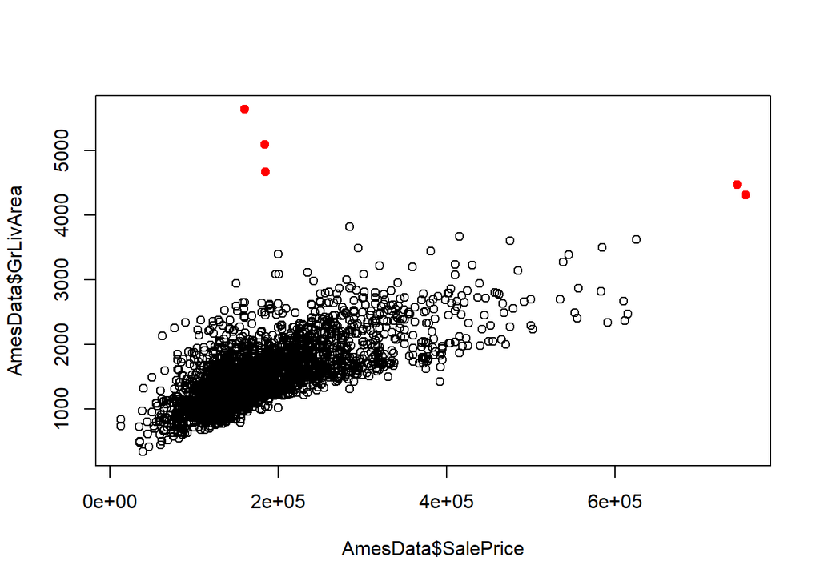

```r
plot(AmesData$SalePrice, AmesData$GrLivArea)
points(AmesData$SalePrice[c(1499, 2181, 2182, 1761, 1768)], AmesData$GrLivArea[c(1499, 2181, 2182, 1761, 1768)], pch = 19, col = 'red')
```

Sort the data by `GrLivArea` to identify the top five houses.

```r
sorted <- AmesData[order(AmesData$GrLivArea, decreasing = TRUE), ]
head(sorted)
```

```
##      Order       PID MSSubClass MSZoning LotFrontage LotArea Street Alley
## 1499  1499 908154235         60       RL         313   63887   Pave  <NA>
## 2181  2181 908154195         20       RL         128   39290   Pave  <NA>
## 2182  2182 908154205         60       RL         130   40094   Pave  <NA>
## 1761  1761 528320050         60       RL         160   15623   Pave  <NA>
## 1768  1768 528351010         60       RL         104   21535   Pave  <NA>
## 1498  1498 908154080         20       RL         123   47007   Pave  <NA>
##      LotShape LandContour Utilities LotConfig LandSlope Neighborhood
## 1499      IR3         Bnk    AllPub    Corner       Gtl      Edwards
## 2181      IR1         Bnk    AllPub    Inside       Gtl      Edwards
## 2182      IR1         Bnk    AllPub    Inside       Gtl      Edwards
## 1761      IR1         Lvl    AllPub    Corner       Gtl      NoRidge
## 1768      IR1         Lvl    AllPub    Corner       Gtl      NoRidge
## 1498      IR1         Lvl    AllPub    Inside       Gtl      Edwards
##      Condition1 Condition2 BldgType HouseStyle OverallQual OverallCond
```

[output cut: 83 more lines]

Check data dimensions.

```r
dim(AmesData)
```

```
## [1] 2930   82
```

Now remove the outliers and visualize the data to see if the operation is complete.

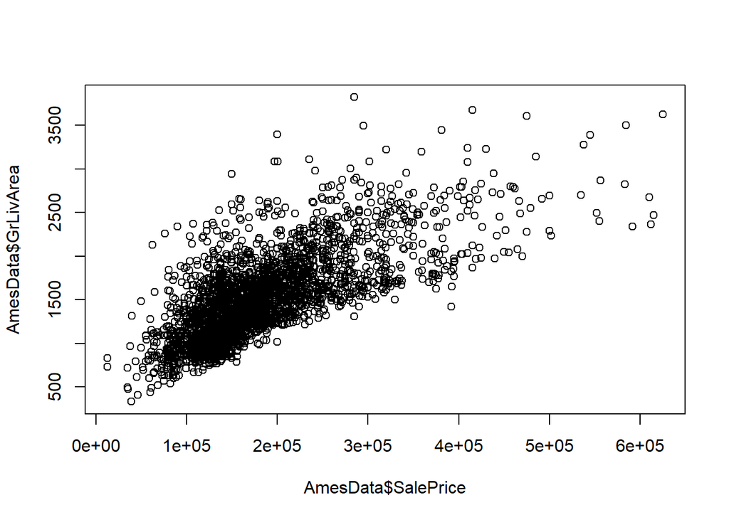

```r
AmesData <- AmesData[-c(1499, 2181, 2182, 1761, 1768), ]
plot(AmesData$SalePrice, AmesData$GrLivArea)
```

Run a sanity check on dimensions just to make sure.

```r
dim(AmesData)
```

```
## [1] 2925   82
```

Check to see the memory footprint of the data file.

```r
pryr::object_size(AmesData)
```

```
## 1.49 MB
```

Look for any duplicates in the data, then run a summary.

```r
anyDuplicated(AmesData)
```

```
## [1] 0
```

```r
summary(AmesData)
```

```
##      Order           PID              MSSubClass      MSZoning
##  Min.   :   1   Min.   :5.263e+08   Min.   : 20.0   Length:2925
##  1st Qu.: 732   1st Qu.:5.285e+08   1st Qu.: 20.0   Class :character
##  Median :1463   Median :5.355e+08   Median : 50.0   Mode  :character
##  Mean   :1465   Mean   :7.144e+08   Mean   : 57.4
##  3rd Qu.:2199   3rd Qu.:9.072e+08   3rd Qu.: 70.0
##  Max.   :2930   Max.   :1.007e+09   Max.   :190.0
##
##   LotFrontage        LotArea          Street             Alley
##  Min.   : 21.00   Min.   :  1300   Length:2925        Length:2925
##  1st Qu.: 58.00   1st Qu.:  7438   Class :character   Class :character
##  Median : 68.00   Median :  9428   Mode  :character   Mode  :character
##  Mean   : 69.02   Mean   : 10104
##  3rd Qu.: 80.00   3rd Qu.: 11515
##  Max.   :313.00   Max.   :215245
##  NA's   :490
##    LotShape         LandContour         Utilities
##  Length:2925        Length:2925        Length:2925
##  Class :character   Class :character   Class :character
##  Mode  :character   Mode  :character   Mode  :character
##
##
##
##
##   LotConfig          LandSlope         Neighborhood
##  Length:2925        Length:2925        Length:2925
##  Class :character   Class :character   Class :character
##  Mode  :character   Mode  :character   Mode  :character
##
##
##
##
##   Condition1         Condition2          BldgType
##  Length:2925        Length:2925        Length:2925
##  Class :character   Class :character   Class :character
##  Mode  :character   Mode  :character   Mode  :character
##
##
##
##
```

[output cut: 121 more lines]

```
##  Length:2925        Min.   :    0.00   Min.   : 1.000   Min.   :2006
##  Class :character   1st Qu.:    0.00   1st Qu.: 4.000   1st Qu.:2007
##  Mode  :character   Median :    0.00   Median : 6.000   Median :2008
##                     Mean   :   44.91   Mean   : 6.217   Mean   :2008
##                     3rd Qu.:    0.00   3rd Qu.: 8.000   3rd Qu.:2009
##                     Max.   :15500.00   Max.   :12.000   Max.   :2010
##
##    SaleType         SaleCondition        SalePrice
##  Length:2925        Length:2925        Min.   : 12789
##  Class :character   Class :character   1st Qu.:129500
##  Mode  :character   Mode  :character   Median :160000
##                                        Mean   :180412
##                                        3rd Qu.:213500
##                                        Max.   :625000
##
```

Check the data structure. Notice it contains character strings and not factors. We specified `stringsAsFactors = FALSE` when we downloaded the file. Characters will be easier to work with, at first.

```r
str(AmesData)
```

```
## 'data.frame':    2925 obs. of  82 variables:
##  $ Order        : int  1 2 3 4 5 6 7 8 9 10 ...
##  $ PID          : int  526301100 526350040 526351010 526353030 527105010 527105030 527127150 527145080 527146030 527162130 ...
##  $ MSSubClass   : int  20 20 20 20 60 60 120 120 120 60 ...
##  $ MSZoning     : chr  "RL" "RH" "RL" "RL" ...
##  $ LotFrontage  : int  141 80 81 93 74 78 41 43 39 60 ...
##  $ LotArea      : int  31770 11622 14267 11160 13830 9978 4920 5005 5389 7500 ...
##  $ Street       : chr  "Pave" "Pave" "Pave" "Pave" ...
##  $ Alley        : chr  NA NA NA NA ...
##  $ LotShape     : chr  "IR1" "Reg" "IR1" "Reg" ...
##  $ LandContour  : chr  "Lvl" "Lvl" "Lvl" "Lvl" ...
##  $ Utilities    : chr  "AllPub" "AllPub" "AllPub" "AllPub" ...
##  $ LotConfig    : chr  "Corner" "Inside" "Corner" "Corner" ...
##  $ LandSlope    : chr  "Gtl" "Gtl" "Gtl" "Gtl" ...
##  $ Neighborhood : chr  "NAmes" "NAmes" "NAmes" "NAmes" ...
```

[output cut: 68 more lines]

Check to see how many empty cells and how many *NA* values we are dealing with. It is in the tens of thousands.

```r
sum(is.na(AmesData))
```

```
## [1] 13944
```

```r
sum(is.empty(AmesData))
```

```
## [1] 48760
```

```r
nan_sums <- colSums(is.na(AmesData))
nan_sums[nan_sums > 0]
```

```
##  LotFrontage        Alley   MasVnrArea     BsmtQual     BsmtCond
##          490         2727           23           79           79
## BsmtExposure BsmtFinType1   BsmtFinSF1 BsmtFinType2   BsmtFinSF2
##           79           79            1           79            1
##    BsmtUnfSF  TotalBsmtSF BsmtFullBath BsmtHalfBath  FireplaceQu
##            1            1            2            2         1422
##   GarageType  GarageYrBlt GarageFinish   GarageCars   GarageArea
##          157          159          157            1            1
##   GarageQual   GarageCond       PoolQC        Fence  MiscFeature
##          158          158         2914         2354         2820
```

For the numeric features, we need to remove the *NA*s and replace them with the median value for the column. First, create the objects that contain the median values.

```r
medianLotFrontage <- median(AmesData$LotFrontage, na.rm = TRUE)
medianMasVnrArea <- median(AmesData$MasVnrArea, na.rm = TRUE)
medianBsmtFinSF1 <- median(AmesData$BsmtFinSF1, na.rm = TRUE)
medianBsmtFinSF2 <- median(AmesData$BsmtFinSF2, na.rm = TRUE)
medianBsmtUnfSF <- median(AmesData$BsmtUnfSF, na.rm = TRUE)
medianTotalBsmtSF <- median(AmesData$TotalBsmtSF, na.rm = TRUE)
medianGarageYrBlt <- median(AmesData$GarageYrBlt, na.rm = TRUE)
medianGarageArea <- median(AmesData$GarageArea, na.rm = TRUE)
```

Second, replace the *NA*s in those columns with the median values.

```r
AmesData$LotFrontage[is.na(AmesData$LotFrontage)] <- medianLotFrontage
AmesData$MasVnrArea[is.na(AmesData$MasVnrArea)] <- medianMasVnrArea
AmesData$BsmtFinSF1[is.na(AmesData$BsmtFinSF1)] <- medianBsmtFinSF1
AmesData$BsmtFinSF2[is.na(AmesData$BsmtFinSF2)] <- medianBsmtFinSF2
AmesData$BsmtUnfSF[is.na(AmesData$BsmtUnfSF)] <- medianBsmtUnfSF
AmesData$TotalBsmtSF[is.na(AmesData$TotalBsmtSF)] <- medianTotalBsmtSF
AmesData$GarageYrBlt[is.na(AmesData$GarageYrBlt)] <- medianGarageYrBlt
AmesData$GarageArea[is.na(AmesData$GarageArea)] <- medianGarageArea
```

Run a sanity check to make sure the changes took.

```r
nan_sums <- colSums(is.na(AmesData))
nan_sums[nan_sums > 0]
```

```
##        Alley     BsmtQual     BsmtCond BsmtExposure BsmtFinType1
##         2727           79           79           79           79
## BsmtFinType2 BsmtFullBath BsmtHalfBath  FireplaceQu   GarageType
##           79            2            2         1422          157
## GarageFinish   GarageCars   GarageQual   GarageCond       PoolQC
##          157            1          158          158         2914
##        Fence  MiscFeature
##         2354         2820
```

```r
sum(is.empty(AmesData))
```

```
## [1] 48107
```

There are many other features missing information. A good way to address them is to make a note the feature does not exist in that particular property. For example, properties without basements cannot have values associated with their basements. So we plug those empty values with a string meaning “without”.

```r
AmesData$Alley[is.na(AmesData$Alley)] <- 'w/o'
AmesData$BsmtQual[is.na(AmesData$BsmtQual)] <- 'w/o'
AmesData$BsmtCond[is.na(AmesData$BsmtCond)] <- 'w/o'
AmesData$BsmtExposure[is.na(AmesData$BsmtExposure)] <- 'w/o'
AmesData$BsmtFinType1[is.na(AmesData$BsmtFinType1)] <- 'w/o'
AmesData$BsmtFinType2[is.na(AmesData$BsmtFinType2)] <- 'w/o'
AmesData$BsmtFullBath[is.na(AmesData$BsmtFullBath)] <- 'w/o'
AmesData$BsmtHalfBath[is.na(AmesData$BsmtHalfBath)] <- 'w/o'
AmesData$FireplaceQu[is.na(AmesData$FireplaceQu)] <- 'w/o'
AmesData$GarageType[is.na(AmesData$GarageType)] <- 'w/o'
AmesData$GarageFinish[is.na(AmesData$GarageFinish)] <- 'w/o'
AmesData$GarageCars[is.na(AmesData$GarageCars)] <- 'w/o'
AmesData$GarageQual[is.na(AmesData$GarageQual)] <- 'w/o'
AmesData$GarageCond[is.na(AmesData$GarageCond)] <- 'w/o'
AmesData$PoolQC[is.na(AmesData$PoolQC)] <- 'w/o'
AmesData$Fence[is.na(AmesData$Fence)] <- 'w/o'
AmesData$MiscFeature[is.na(AmesData$MiscFeature)] <- 'w/o'
```

The character features need to be converted back to factors for the rest of the analysis. Looking at data structure again confirms a successful conversion.

```r
AmesData <- as.data.frame(unclass(AmesData))
str(AmesData)
```

```
## 'data.frame':    2925 obs. of  82 variables:
##  $ Order        : int  1 2 3 4 5 6 7 8 9 10 ...
##  $ PID          : int  526301100 526350040 526351010 526353030 527105010 527105030 527127150 527145080 527146030 527162130 ...
##  $ MSSubClass   : int  20 20 20 20 60 60 120 120 120 60 ...
##  $ MSZoning     : Factor w/ 7 levels "A (agr)","C (all)",..: 6 5 6 6 6 6 6 6 6 6 ...
##  $ LotFrontage  : int  141 80 81 93 74 78 41 43 39 60 ...
##  $ LotArea      : int  31770 11622 14267 11160 13830 9978 4920 5005 5389 7500 ...
##  $ Street       : Factor w/ 2 levels "Grvl","Pave": 2 2 2 2 2 2 2 2 2 2 ...
##  $ Alley        : Factor w/ 3 levels "Grvl","Pave",..: 3 3 3 3 3 3 3 3 3 3 ...
##  $ LotShape     : Factor w/ 4 levels "IR1","IR2","IR3",..: 1 4 1 4 1 1 4 1 1 4 ...
##  $ LandContour  : Factor w/ 4 levels "Bnk","HLS","Low",..: 4 4 4 4 4 4 4 2 4 4 ...
##  $ Utilities    : Factor w/ 3 levels "AllPub","NoSeWa",..: 1 1 1 1 1 1 1 1 1 1 ...
##  $ LotConfig    : Factor w/ 5 levels "Corner","CulDSac",..: 1 5 1 1 5 5 5 5 5 5 ...
##  $ LandSlope    : Factor w/ 3 levels "Gtl","Mod","Sev": 1 1 1 1 1 1 1 1 1 1 ...
##  $ Neighborhood : Factor w/ 28 levels "Blmngtn","Blueste",..: 16 16 16 16 9 9 25 25 25 9 ...
```

[output cut: 68 more lines]

The goal isn’t to remove all empty values. Many are legitimate data that should be preserved. Run a count to see how many remain.

```r
sum(is.empty(AmesData))
```

```
## [1] 30190
```

There are two features that contain empty values that cannot be treated as “withouts” or with median values. For those – *MasVnrType* and *Electrical* – we need to find alternative values. We cannot say a property is without an electrical system but we can use the most common type of electrical system as a proxy.

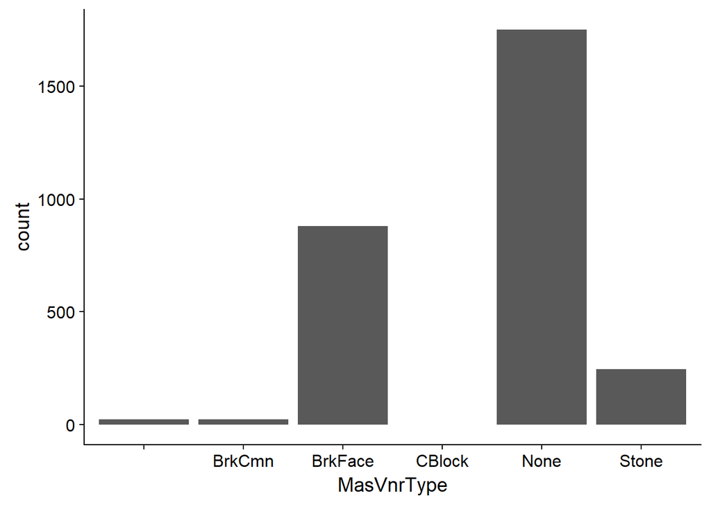

```r
ggplot(AmesData, aes(x = MasVnrType)) + geom_histogram(stat = 'count')
```

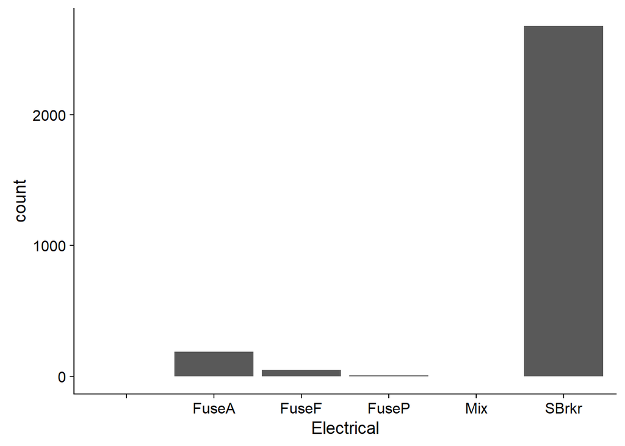

```r
ggplot(AmesData, aes(x = Electrical)) + geom_histogram(stat = 'count')
```

It looks like the most common type of *MasVnrType* is “None.” For *Electrical* it looks like “SBrkr” so we can use those to replace the empty values. We run a count to make sure the changes took hold.

```r
AmesData$MasVnrType[AmesData$MasVnrType == ''] <- 'None'
AmesData$Electrical[AmesData$Electrical == ''] <- 'SBrkr'
nan_sums <- colSums(is.na(AmesData))
nan_sums[nan_sums > 0]
```

```
## named numeric(0)
```

```r
sum(is.empty(AmesData$Electrical))
```

```
## [1] 0
```

```r
sum(is.empty(AmesData$MasVnrType))
```

```
## [1] 0
```

```r
sum(is.empty(AmesData))
```

```
## [1] 30190
```

### Data Explanations

For the remaining operations, particular the graphics involving the *ggplot2* package, it will be helpful to convert the data into the *tibble* data frame format for ease of use.

```r
AmesTibble <- as_tibble(AmesData)
AmesTibble
```

```
## # A tibble: 2,925 x 82
##    Order       PID MSSubClass MSZoning LotFrontage LotArea Street Alley
##    <int>     <int>      <int> <fct>          <int>   <int> <fct>  <fct>
##  1     1 526301100         20 RL               141   31770 Pave   w/o
##  2     2 526350040         20 RH                80   11622 Pave   w/o
##  3     3 526351010         20 RL                81   14267 Pave   w/o
##  4     4 526353030         20 RL                93   11160 Pave   w/o
##  5     5 527105010         60 RL                74   13830 Pave   w/o
##  6     6 527105030         60 RL                78    9978 Pave   w/o
##  7     7 527127150        120 RL                41    4920 Pave   w/o
##  8     8 527145080        120 RL                43    5005 Pave   w/o
##  9     9 527146030        120 RL                39    5389 Pave   w/o
## 10    10 527162130         60 RL                60    7500 Pave   w/o
## # ... with 2,915 more rows, and 74 more variables: LotShape <fct>,
## #   LandContour <fct>, Utilities <fct>, LotConfig <fct>, LandSlope <fct>,
## #   Neighborhood <fct>, Condition1 <fct>, Condition2 <fct>,
## #   BldgType <fct>, HouseStyle <fct>, OverallQual <int>,
## #   OverallCond <int>, YearBuilt <int>, YearRemodAdd <int>,
## #   RoofStyle <fct>, RoofMatl <fct>, Exterior1st <fct>, Exterior2nd <fct>,
## #   MasVnrType <fct>, MasVnrArea <dbl>, ExterQual <fct>, ExterCond <fct>,
## #   Foundation <fct>, BsmtQual <fct>, BsmtCond <fct>, BsmtExposure <fct>,
## #   BsmtFinType1 <fct>, BsmtFinSF1 <dbl>, BsmtFinType2 <fct>,
## #   BsmtFinSF2 <dbl>, BsmtUnfSF <dbl>, TotalBsmtSF <dbl>, Heating <fct>,
## #   HeatingQC <fct>, CentralAir <fct>, Electrical <fct>, X1stFlrSF <int>,
## #   X2ndFlrSF <int>, LowQualFinSF <int>, GrLivArea <int>,
## #   BsmtFullBath <fct>, BsmtHalfBath <fct>, FullBath <int>,
## #   HalfBath <int>, BedroomAbvGr <int>, KitchenAbvGr <int>,
## #   KitchenQual <fct>, TotRmsAbvGrd <int>, Functional <fct>,
## #   Fireplaces <int>, FireplaceQu <fct>, GarageType <fct>,
## #   GarageYrBlt <dbl>, GarageFinish <fct>, GarageCars <fct>,
## #   GarageArea <dbl>, GarageQual <fct>, GarageCond <fct>,
## #   PavedDrive <fct>, WoodDeckSF <int>, OpenPorchSF <int>,
## #   EnclosedPorch <int>, X3SsnPorch <int>, ScreenPorch <int>,
## #   PoolArea <int>, PoolQC <fct>, Fence <fct>, MiscFeature <fct>,
## #   MiscVal <int>, MoSold <int>, YrSold <int>, SaleType <fct>,
## #   SaleCondition <fct>, SalePrice <int>
```

Contingency tables are useful to get a sense of how many levels exist for different features, and how many properties fall into each category. Contingency tables can count information or percentages of total instances. Graphic representations of the data in the tables are also useful. Contingecy tables and histograms help us understand the frequency of features, or how often we encounter them in the data set.

In this way, we can see if any particular housing features dominate in the Ames real estate market. We get an understanding of what a typical or representative property might look like.

To illustrate, here are two contingency tables for the *OverallCond* feature, along with a histogram of the distribution.

```r
table(AmesTibble$OverallCond)
```

```
##
##    1    2    3    4    5    6    7    8    9
##    7   10   50  101 1650  532  390  144   41
```

```r
round(table(AmesTibble$OverallCond)/length(AmesTibble$OverallCond), 3)
```

```
##
##     1     2     3     4     5     6     7     8     9
## 0.002 0.003 0.017 0.035 0.564 0.182 0.133 0.049 0.014
```

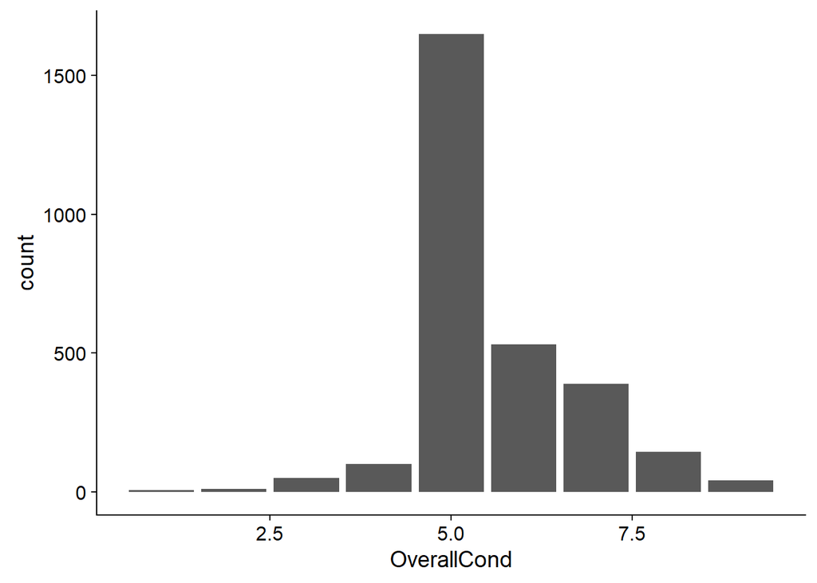

```r
ggplot(AmesData, aes(x = OverallCond)) + geom_histogram(stat = 'count')
```

The table on *OverallCond* shows what we might expect – most houses are in the middle. They are in average condition.

Roof features – the style of roof and the roofing material used – are also of interest. They tell us something about the architecture and construction of properties. Here are contingency tables and histrograms of each.

```r
table(AmesTibble$RoofStyle)
```

```
##
##    Flat   Gable Gambrel     Hip Mansard    Shed
##      20    2320      22     547      11       5
```

```r
round(table(AmesTibble$RoofStyle)/length(AmesTibble$RoofStyle), 3)
```

```
##
##    Flat   Gable Gambrel     Hip Mansard    Shed
##   0.007   0.793   0.008   0.187   0.004   0.002
```

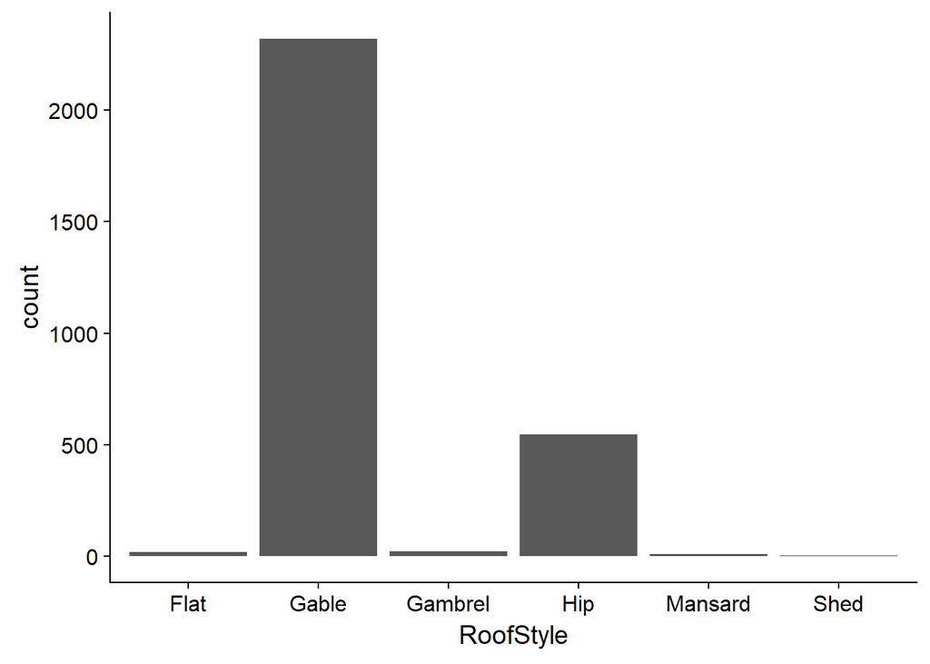

```r
ggplot(AmesTibble, aes(x = RoofStyle)) + geom_histogram(stat = 'count')
```

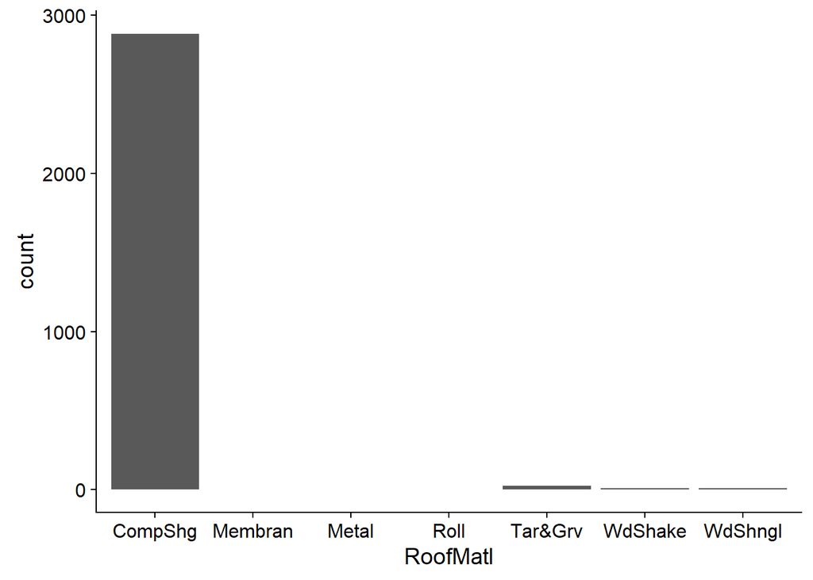

```r
ggplot(AmesTibble, aes(x = RoofMatl)) + geom_histogram(stat = 'count')
```

What we see is two types of structure – Gable and Hip – are prevalent in architectural style of Ames houses. Gable dominates by far. We also see that virtually all rooves are made of composite shingles.

Since roof features can be broken down into two subcategories – style and material – we can classify rooves both ways and construct a table to represent what materials are associated with which styles.

```r
RoofTable <- table(AmesTibble$RoofStyle, AmesTibble$RoofMatl)
DecTable <- table(AmesTibble$RoofStyle, AmesTibble$RoofMatl)/length(AmesData$RoofStyle)
DecTable <- round(DecTable, 3)
RoofTable
```

```
##
##           CompShg Membran Metal Roll Tar&Grv WdShake WdShngl
##   Flat          1       1     1    0      17       0       0
##   Gable      2309       0     0    1       6       0       4
##   Gambrel      22       0     0    0       0       0       0
##   Hip         541       0     0    0       0       5       1
##   Mansard       8       0     0    0       0       3       0
##   Shed          3       0     0    0       0       1       1
```

```r
DecTable
```

```
##
##           CompShg Membran Metal  Roll Tar&Grv WdShake WdShngl
##   Flat      0.000   0.000 0.000 0.000   0.006   0.000   0.000
##   Gable     0.789   0.000 0.000 0.000   0.002   0.000   0.001
##   Gambrel   0.008   0.000 0.000 0.000   0.000   0.000   0.000
##   Hip       0.185   0.000 0.000 0.000   0.000   0.002   0.000
##   Mansard   0.003   0.000 0.000 0.000   0.000   0.001   0.000
##   Shed      0.001   0.000 0.000 0.000   0.000   0.000   0.000
```

The tables above give us the count and proportions of each combination of roofing style and material in the Ames market. It seems the choices are pretty limited there.

A graphic way to represent this information is a balloon plot. The size of the balloon indicates the count associated with each combination of style and material.

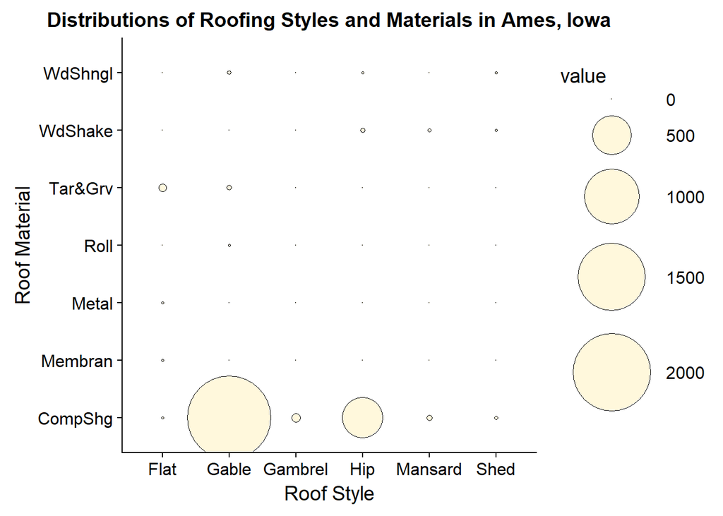

```r
AmesRoofMelt <- melt(RoofTable)
ggplot(AmesRoofMelt, aes(Var.1, Var.2)) +
        geom_point(aes(size = value), shape = 21, color = 'black', fill = 'cornsilk') +
        scale_size_area(max_size = 27) +
        ggtitle('Distributions of Roofing Styles and Materials in Ames, Iowa') +
        labs(x = 'Roof Style', y = 'Roof Material') +
        theme(panel.background = element_blank(),
              panel.border = element_rect(color = 'blue', fill = NA, size = 1))
```

The balloon plot is a visual representation of the same information contained in the tables preceding it.

We can compare any two features against each other to get a sense of the relationship between them. This is not practical for all features in such a large data set, and many comparisons would be meaningless, but we can select some features of interest and look for patterns there. The pair plots below consider six numerical features. Colors indiate the size of the garages associated with each property, in terms of the number of cars each garage can hold.

For our purpose, the *SalePrice* is the target for our analysis. We want to know how the other variables impact the value of the home when it comes time to sell.

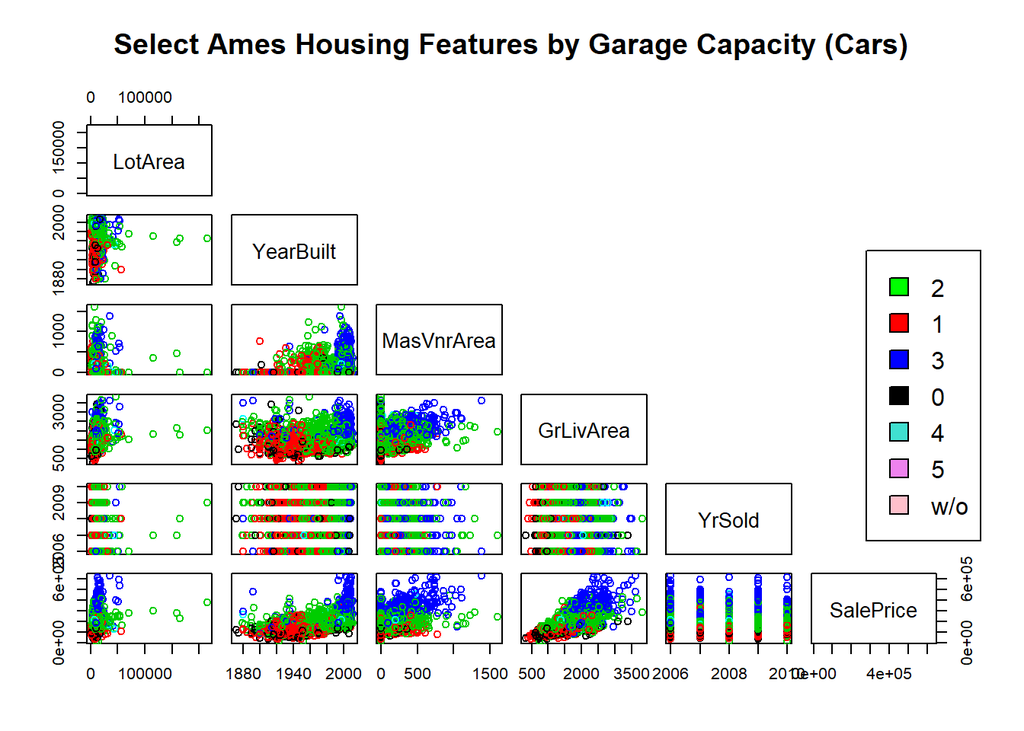

```r
AmesPairs <- AmesTibble[c(6, 21, 28, 48, 79, 82)]
pairs(AmesPairs, upper.panel = NULL, col = AmesTibble$GarageCars,
      main = 'Select Ames Housing Features by Garage Capacity (Cars)')
par(xpd = TRUE)
legend(0.9, 0.7, as.vector(unique(AmesTibble$GarageCars)),
       fill = c('green', 'red', 'blue', 'black', 'turquoise', 'violet', 'pink'))
```

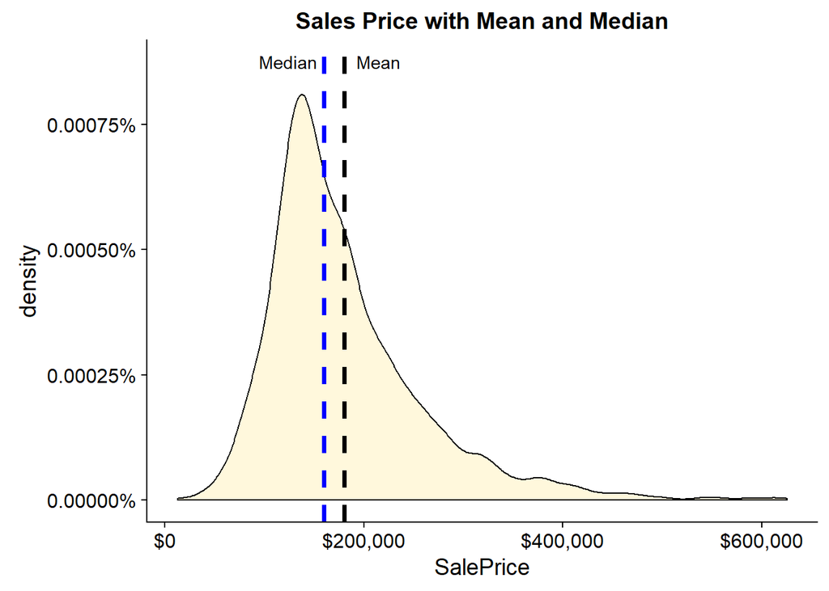

```r
ggplot(AmesTibble, aes(x = SalePrice)) + geom_density(fill = 'cornsilk') +
        geom_vline(aes(xintercept = mean(SalePrice)), color = 'black',
                   linetype = 'dashed', size = 1.25) +
        geom_vline(aes(xintercept = median(SalePrice)), color = 'blue',
                   linetype = 'dashed', size = 1.25) +
        ggtitle('Sales Price with Mean and Median') +
        annotate(geom = 'text', x = 215000, y = 0.00000875, label = 'Mean') +
        annotate(geom = 'text', x = 124000, y = 0.00000875, label = 'Median') +
        scale_x_continuous(labels = scales::dollar) +
        scale_y_continuous(labels = scales::percent)
```

The previous graph gives an idea of the aggregate distribution of *SalePrice* for all properties in the city of Ames. Another way to look at the distribution of sales prices is by neighborhood. Box plots are useful for this. The white diamond in the body of the box plot indicates mean value. *SalePrice* is numeric while *Neighborhood* is a factor.

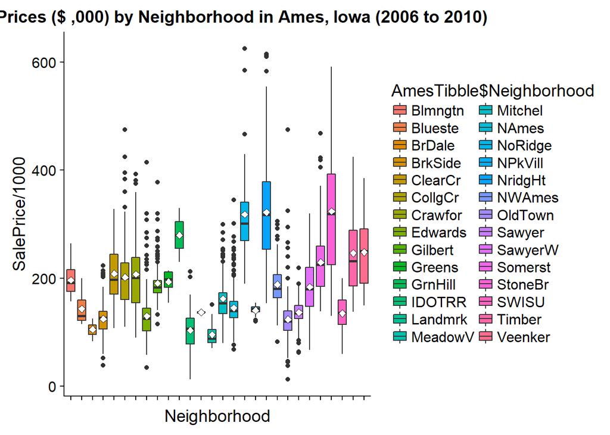

```r
ggplot(AmesTibble, aes(x = Neighborhood, y = SalePrice/1000)) +
        geom_boxplot(aes(fill = AmesTibble$Neighborhood)) +
        stat_summary(fun.y = 'mean', geom = 'point', shape = 23, size = 2,
                     fill = 'white') +
        ggtitle("Sales Prices ($ ,000) by Neighborhood in Ames, Iowa (2006 to 2010)") +
        theme(axis.text.x=element_blank())
```

We can see in the box plots which neighborhoods are the least and most popular, the least and most valuable, and which contain mostly less expensive homes, or the more expensive ones. This detail is not available in the density chart above, which give an average value for all homes. Here, we see the average value and the range of values by neighborhood.

### Determining the Importance of Features

Many factors in the data need to be converted to dummy variables in order to include them in the analysis. Dummy variables are used to allow non-numeric features to be used in statistical analyses. Look at the data structure afterwards to make sure the changes occurred and the new dummy columns were added.

```r
AmesDummy <- dummy_cols(AmesTibble, remove_first_dummy = TRUE)
str(AmesDummy)
```

```
## Classes 'tbl_df', 'tbl' and 'data.frame':    2925 obs. of  340 variables:
##  $ Order                : int  1 2 3 4 5 6 7 8 9 10 ...
##  $ PID                  : int  526301100 526350040 526351010 526353030 527105010 527105030 527127150 527145080 527146030 527162130 ...
##  $ MSSubClass           : int  20 20 20 20 60 60 120 120 120 60 ...
##  $ MSZoning             : Factor w/ 7 levels "A (agr)","C (all)",..: 6 5 6 6 6 6 6 6 6 6 ...
##  $ LotFrontage          : int  141 80 81 93 74 78 41 43 39 60 ...
##  $ LotArea              : int  31770 11622 14267 11160 13830 9978 4920 5005 5389 7500 ...
##  $ Street               : Factor w/ 2 levels "Grvl","Pave": 2 2 2 2 2 2 2 2 2 2 ...
##  $ Alley                : Factor w/ 3 levels "Grvl","Pave",..: 3 3 3 3 3 3 3 3 3 3 ...
##  $ LotShape             : Factor w/ 4 levels "IR1","IR2","IR3",..: 1 4 1 4 1 1 4 1 1 4 ...
##  $ LandContour          : Factor w/ 4 levels "Bnk","HLS","Low",..: 4 4 4 4 4 4 4 2 4 4 ...
##  $ Utilities            : Factor w/ 3 levels "AllPub","NoSeWa",..: 1 1 1 1 1 1 1 1 1 1 ...
##  $ LotConfig            : Factor w/ 5 levels "Corner","CulDSac",..: 1 5 1 1 5 5 5 5 5 5 ...
##  $ LandSlope            : Factor w/ 3 levels "Gtl","Mod","Sev": 1 1 1 1 1 1 1 1 1 1 ...
##  $ Neighborhood         : Factor w/ 28 levels "Blmngtn","Blueste",..: 16 16 16 16 9 9 25 25 25 9 ...
```

[output cut: 87 more lines]

The dummies were created in preparation for scaling the features. We don’t want to scale the target, *SalePrice*, so we remove that from the main data set and put it into its own object. The dummies are numeric representations of factors, expressed as zeroes and ones. With the dummies created, we don’t need the factors in the data set anymore so we remove them. Run a sanity check to make sure all looks good.

```r
AmesDumNoTg <- AmesDummy[, -82]
AmesTarget <- AmesDummy[, 82]
names(Filter(is.factor, AmesDumNoTg))
```

```
##  [1] "MSZoning"      "Street"        "Alley"         "LotShape"
##  [5] "LandContour"   "Utilities"     "LotConfig"     "LandSlope"
##  [9] "Neighborhood"  "Condition1"    "Condition2"    "BldgType"
## [13] "HouseStyle"    "RoofStyle"     "RoofMatl"      "Exterior1st"
## [17] "Exterior2nd"   "MasVnrType"    "ExterQual"     "ExterCond"
## [21] "Foundation"    "BsmtQual"      "BsmtCond"      "BsmtExposure"
## [25] "BsmtFinType1"  "BsmtFinType2"  "Heating"       "HeatingQC"
## [29] "CentralAir"    "Electrical"    "BsmtFullBath"  "BsmtHalfBath"
## [33] "KitchenQual"   "Functional"    "FireplaceQu"   "GarageType"
## [37] "GarageFinish"  "GarageCars"    "GarageQual"    "GarageCond"
## [41] "PavedDrive"    "PoolQC"        "Fence"         "MiscFeature"
## [45] "SaleType"      "SaleCondition"
```

```r
dropCols <- c("MSZoning", "Street", "Alley", "LotShape", "LandContour", "Utilities",
              "LotConfig", "LandSlope", "Neighborhood", "Condition1", "Condition2",
              "BldgType", "HouseStyle", "RoofStyle", "RoofMatl", "Exterior1st",
              "Exterior2nd", "MasVnrType", "ExterQual", "ExterCond", "Foundation",
              "BsmtQual", "BsmtCond", "BsmtExposure", "BsmtFinType1", "BsmtFinType2",
              "Heating", "HeatingQC", "CentralAir", "Electrical", "BsmtFullBath",
              "BsmtHalfBath", "KitchenQual", "Functional", "FireplaceQu", "GarageType",
              "GarageFinish", "GarageCars", "GarageQual", "GarageCond", "PavedDrive",
              "PoolQC", "Fence", "MiscFeature", "SaleType", "SaleCondition")
AmesDumNoTg <- AmesDumNoTg %>% dplyr::select(-one_of(dropCols))
dim(AmesDumNoTg)
```

```
## [1] 2925  293
```

Now that our data are in shape and all features are numeric, it is time to scale the data. Once scaled, we need to convert the data back into *tibble* format.

```r
AmesDumScale <- scale(AmesDumNoTg, center = TRUE, scale = TRUE)
AmesDumScaleDF <- as.tibble(AmesDumScale)
```

Again, the number of features in this data set is too large to show all transformations, but we can select a few to look at. The point of scaling is that the distributions do not change. All that is impacted is the scale of the x-axis. We can see these characteristics in the plots that follow.

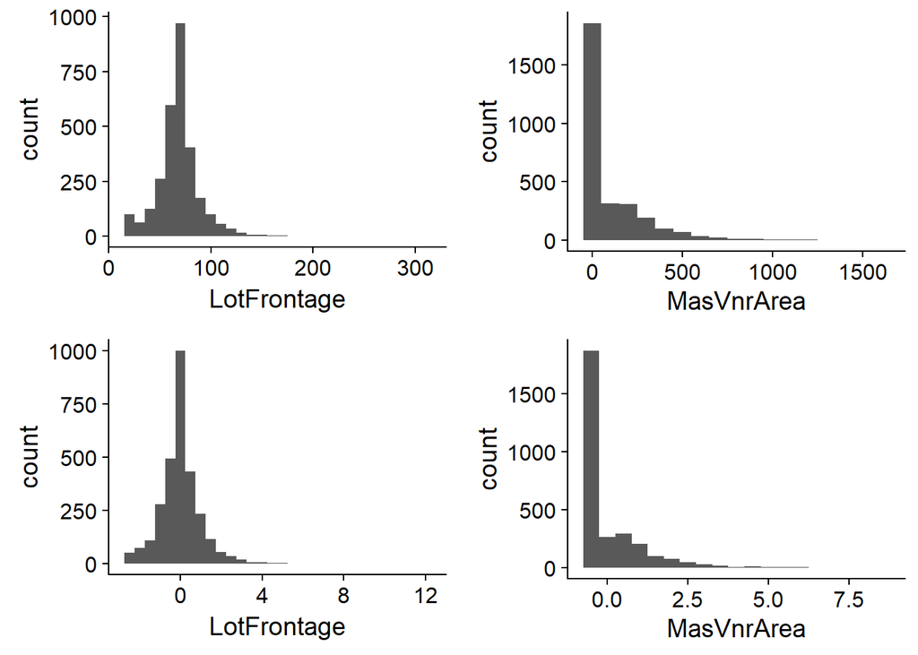

```r
p1 <- ggplot(AmesTibble, aes(x = LotFrontage)) + geom_histogram(binwidth = 10)
p2 <- ggplot(AmesDumScaleDF, aes(x = LotFrontage)) + geom_histogram(binwidth = .5)
p3 <- ggplot(AmesTibble, aes(x = MasVnrArea)) + geom_histogram(binwidth = 100)
p4 <- ggplot(AmesDumScaleDF, aes(x = MasVnrArea)) + geom_histogram(binwidth = .5)
p5 <- ggplot(AmesTibble, aes(x = GrLivArea)) + geom_histogram(binwidth = 250)
p6 <- ggplot(AmesDumScaleDF, aes(x = GrLivArea)) + geom_histogram(binwidth = .5)
p7 <- ggplot(AmesTibble, aes(x = GarageArea)) + geom_histogram(binwidth = 100)
p8 <- ggplot(AmesDumScaleDF, aes(x = GarageArea)) + geom_histogram(binwidth = .45)
grid.arrange(p1, p3, p2, p4, nrow = 2)
```

These plots also exhibit no change in distribution, just different x-axis values.

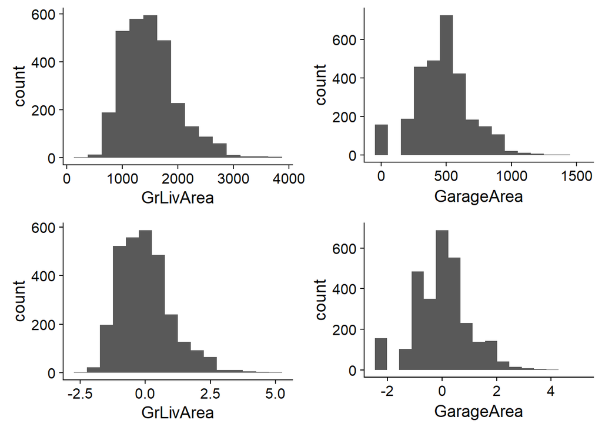

```r
grid.arrange(p5, p7, p6, p8, nrow = 2)
```

With the data dummified and scaled, it is time to turn attention to the task of figuring out which of the now nearly 300 features are the most important for the purpose of modelling and predicting *SalePrice*. We need to rejoin the target to the data set in order to do this.

There are a variety of methods we can use to identify candidates for the most important features. This data set is designed for multilinear analysis, so we start with that. But let’s take an intuitive guess as to which 10 features are the most important. We can compare the guesstimates to the statistical analysis later.

```r
Top10Intuitive <- c('LotArea', 'LotFrontage', 'Neighborhood', 'GrLivArea',
                    'PoolArea', 'X1stFlrSF', 'X2ndFlrSF', 'TotalBsmtSF',
                    'GarageArea', 'KitchenQual')
tibble(Top10Intuitive)
```

```
## # A tibble: 10 x 1
##    Top10Intuitive
##    <chr>
##  1 LotArea
##  2 LotFrontage
##  3 Neighborhood
##  4 GrLivArea
##  5 PoolArea
##  6 X1stFlrSF
##  7 X2ndFlrSF
##  8 TotalBsmtSF
##  9 GarageArea
## 10 KitchenQual
```

```r
AmesDumScaleDF <- cbind(AmesTarget, AmesDumScaleDF)
```

A linear model can be built to identify the top 10 features, based on the value of the estimates each feature is assigned by the model.

```r
lmRating <- lm(SalePrice ~ . , AmesDumScaleDF)
lmCoefs <- tidy(lmRating)
lmCoefs$abs_est <- sqrt(lmCoefs$estimate^2)
lmCoefsAbs <- lmCoefs[-c(2:5)]
lmCoefsAbs <- lmCoefsAbs[-1,]
head(lmCoefsAbs[order(-lmCoefsAbs$abs_est), ], 10)
```

```
##                    term    abs_est
## 15          TotalBsmtSF 123574.857
## 14            BsmtUnfSF 120415.319
## 12           BsmtFinSF1 111278.962
## 13           BsmtFinSF2  44059.849
## 17            X2ndFlrSF  26468.549
## 16            X1stFlrSF  20332.979
## 123 Exterior1st_VinylSd  11834.644
## 32             PoolArea   9796.983
## 9             YearBuilt   9606.780
## 7           OverallQual   8777.383
```

The top 10 features are listed above, but let’s use the same method to identify the least important features, as well.

```r
tail(lmCoefsAbs[order(-lmCoefsAbs$abs_est), ], 10)
```

```
##                   term   abs_est
## 230 GarageType_Basment 50.570919
## 91     Condition1_PosA 40.573687
## 203   Electrical_FuseA 38.236848
## 108    HouseStyle_SLvl 34.245808
## 30          X3SsnPorch 22.521423
## 205   Electrical_FuseP 11.404369
## 211     BsmtHalfBath_1  9.120788
## 262   MiscFeature_Shed  8.161129
## 121      RoofMatl_Roll  7.673177
## 100    Condition2_RRAn  2.343051
```

Apparently, the electrical fuse box is not a consideration when buying a home or determining its price.

Next, lassos will be employed to identify the top 10 features. The first effort will use a Gaussian distribution. The aim here is to minimize lambda using cross validation. The `cv.glmnet()` command uses the squared-error as the loss function. We can plot the values of lambda as they minimize across the features.

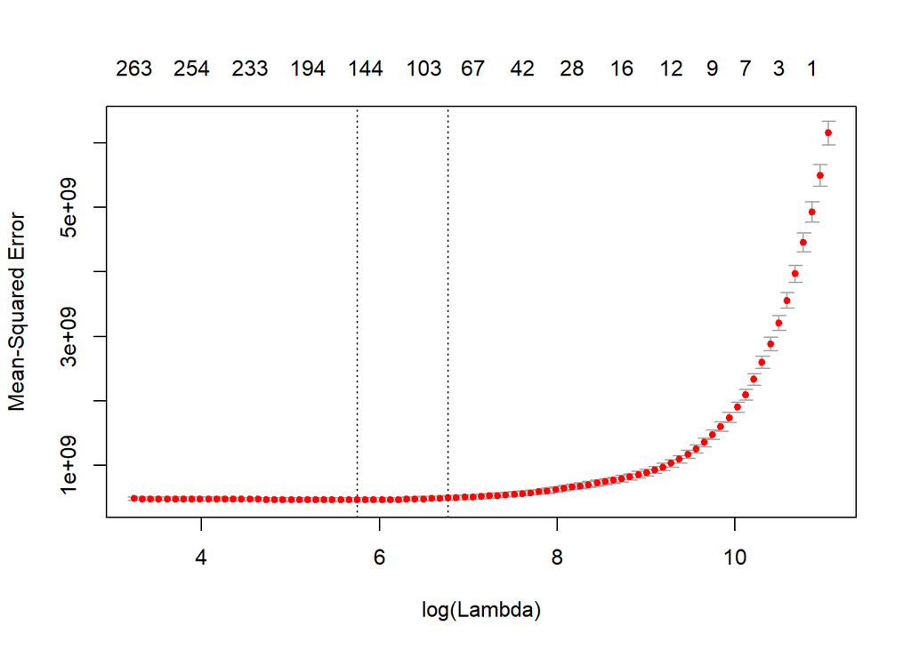

```r
x <- as.matrix(AmesDumScaleDF[, -1])
y <- as.matrix(AmesDumScaleDF[, 1])
set.seed(805)
cv.ridge.g <- cv.glmnet(x, y, family = 'gaussian')
plot(cv.ridge.g)
```

Running through the analysis yields the top 10 features the Guassian lasso identifies. The bottom 10 are also included.

```r
cv.ridge.g$lambda.min
```

```
## [1] 314.7688
```

```r
cv.ridge.g$lambda.1se
```

```
## [1] 875.8628
```

```r
LassoCoefsG <- coef(cv.ridge.g, s = cv.ridge.g$lambda.min)
LassoCoefsG <- tidy(LassoCoefsG)
LassoCoefsG$abs_est <- sqrt(LassoCoefsG$value^2)
LassoCoefsG <- LassoCoefsG[-c(2:3)]
LassoCoefsG <- LassoCoefsG[-1,]
head(LassoCoefsG[order(-LassoCoefsG$abs_est), ], 10)
```

```
##                 row   abs_est
## 14        GrLivArea 27445.891
## 5       OverallQual 10817.574
## 7         YearBuilt  8060.114
## 10       BsmtFinSF1  7882.249
## 12      TotalBsmtSF  7648.576
## 6       OverallCond  5589.734
## 101 BsmtExposure_No  5442.511
## 141    GarageCars_3  5406.970
## 93     ExterQual_Ex  4983.285
## 99      BsmtQual_Ex  4874.542
```

```r
tail(LassoCoefsG[order(-LassoCoefsG$abs_est), ], 10)
```

```
##                      row    abs_est
## 136       FireplaceQu_Fa 22.7398430
## 138   GarageType_CarPort 15.5561731
## 44   Neighborhood_BrDale 13.8200880
## 109     BsmtFinType2_BLQ 11.9114936
## 94          ExterQual_Fa 10.3457489
## 85   Exterior2nd_CmentBd  8.7584850
## 156 SaleCondition_Alloca  8.6983484
## 153         SaleType_CWD  3.5121652
## 87   Exterior2nd_PreCast  1.5589606
## 78   Exterior1st_CemntBd  0.7499508
```

Next, we will use a lasso with a Poisson distribution to see if it yields different results. Here, the loss fucntion is represented by deviance. Top and bottom features are displayed.

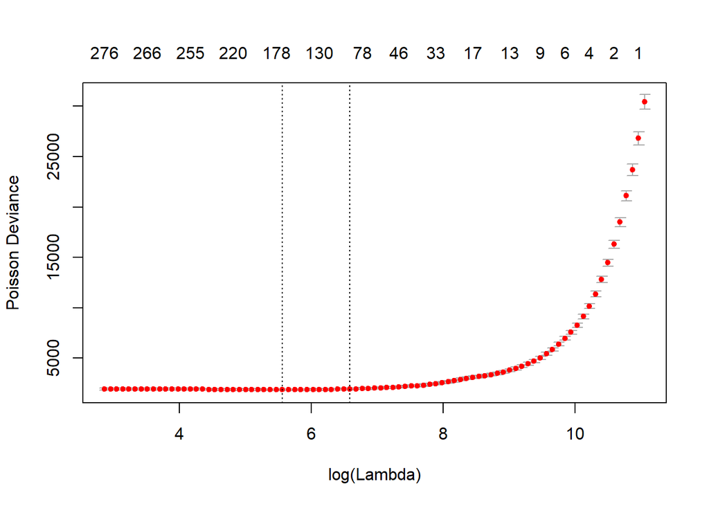

```r
set.seed(805)
cv.ridge.p <- cv.glmnet(x, y, family = 'poisson')
plot(cv.ridge.p)
```

Running through the analysis identifies the top 10 features for the Poisson lasso.

```r
cv.ridge.p$lambda.min
```

```
## [1] 261.3266
```

```r
cv.ridge.p$lambda.1se
```

```
## [1] 727.1567
```

```r
LassoCoefsP <- coef(cv.ridge.p, s = cv.ridge.p$lambda.min)
LassoCoefsP <- tidy(LassoCoefsP)
LassoCoefsP$abs_est <- sqrt(LassoCoefsP$value^2)
LassoCoefsP <- LassoCoefsP[-c(2:3)]
LassoCoefsP <- LassoCoefsP[-1,]
head(LassoCoefsP[order(-LassoCoefsP$abs_est), ], 10)
```

```
##                     row    abs_est
## 17            GrLivArea 0.12731172
## 7           OverallQual 0.07689086
## 9             YearBuilt 0.05551847
## 14          TotalBsmtSF 0.04153414
## 8           OverallCond 0.03968042
## 12           BsmtFinSF1 0.03090506
## 24           GarageArea 0.02125383
## 57 Neighborhood_Crawfor 0.02015258
## 31          MSZoning_RM 0.01755636
## 10         YearRemodAdd 0.01688563
```

```r
tail(LassoCoefsP[order(-LassoCoefsP$abs_est), ], 10)
```

```
##                     row      abs_est
## 151        GarageCars_4 3.962979e-05
## 86  Exterior2nd_Wd Shng 3.513499e-05
## 111    BsmtFinType1_w/o 1.931424e-05
## 155       GarageQual_Po 1.570485e-05
## 156      GarageCond_w/o 1.036835e-05
## 126      BsmtFullBath_2 1.035090e-05
## 150        GarageCars_0 9.358394e-06
## 114    BsmtFinType2_w/o 8.298147e-06
## 37         LotShape_IR3 6.553659e-06
## 129    BsmtHalfBath_w/o 7.497908e-17
```

Of the two lasso procedures, it appears the Poisson distribution is most useful because its lambda values are lower.

Next, we will use a Gradient Boost Method for the same purpose.

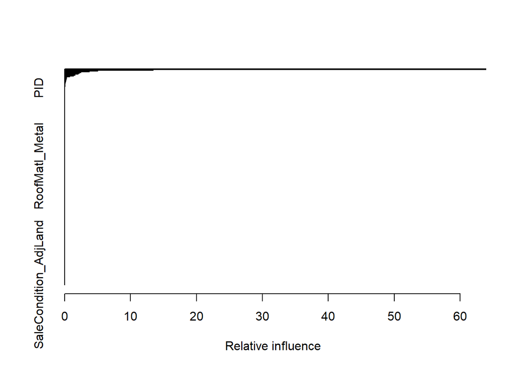

```
##                                         var     rel.inf
## OverallQual                     OverallQual 63.90282548
## GrLivArea                         GrLivArea 13.40399035
## GarageCars_3                   GarageCars_3  5.02478512
## TotalBsmtSF                     TotalBsmtSF  3.77016254
## BsmtQual_Ex                     BsmtQual_Ex  2.46371610
## X1stFlrSF                         X1stFlrSF  2.20032001
## YearBuilt                         YearBuilt  2.05638089
## FullBath                           FullBath  1.56479915
## GarageArea                       GarageArea  1.56196647
## BsmtFinSF1                       BsmtFinSF1  1.37285135
## KitchenQual_Ex               KitchenQual_Ex  0.74520205
## LotArea                             LotArea  0.31820903
## ExterQual_Ex                   ExterQual_Ex  0.28286206
## MasVnrArea                       MasVnrArea  0.25490636
## X2ndFlrSF                         X2ndFlrSF  0.22180169
## YearRemodAdd                   YearRemodAdd  0.17593074
## Fireplaces                       Fireplaces  0.16488555
## KitchenQual_Gd               KitchenQual_Gd  0.13942962
## `FireplaceQu_w/o`         `FireplaceQu_w/o`  0.11327372
## ExterQual_Gd                   ExterQual_Gd  0.07676505
## BsmtQual_Gd                     BsmtQual_Gd  0.05163028
## CentralAir_N                   CentralAir_N  0.04718140
## GarageType_Detchd         GarageType_Detchd  0.04702996
## MSZoning_RM                     MSZoning_RM  0.03909503
## Order                                 Order  0.00000000
## PID                                     PID  0.00000000
## MSSubClass                       MSSubClass  0.00000000
## LotFrontage                     LotFrontage  0.00000000
## OverallCond                     OverallCond  0.00000000
## BsmtFinSF2                       BsmtFinSF2  0.00000000
## BsmtUnfSF                         BsmtUnfSF  0.00000000
## LowQualFinSF                   LowQualFinSF  0.00000000
## HalfBath                           HalfBath  0.00000000
## BedroomAbvGr                   BedroomAbvGr  0.00000000
## KitchenAbvGr                   KitchenAbvGr  0.00000000
## TotRmsAbvGrd                   TotRmsAbvGrd  0.00000000
## GarageYrBlt                     GarageYrBlt  0.00000000
## WoodDeckSF                       WoodDeckSF  0.00000000
## OpenPorchSF                     OpenPorchSF  0.00000000
```

[output cut: 239 more lines]

```
## MiscFeature_TenC           MiscFeature_TenC  0.00000000
## SaleType_New                   SaleType_New  0.00000000
## SaleType_COD                   SaleType_COD  0.00000000
## SaleType_ConLI               SaleType_ConLI  0.00000000
## SaleType_Con                   SaleType_Con  0.00000000
## SaleType_ConLD               SaleType_ConLD  0.00000000
## SaleType_Oth                   SaleType_Oth  0.00000000
## SaleType_ConLw               SaleType_ConLw  0.00000000
## SaleType_CWD                   SaleType_CWD  0.00000000
## SaleType_VWD                   SaleType_VWD  0.00000000
## SaleCondition_Partial SaleCondition_Partial  0.00000000
## SaleCondition_Family   SaleCondition_Family  0.00000000
## SaleCondition_Abnorml SaleCondition_Abnorml  0.00000000
## SaleCondition_Alloca   SaleCondition_Alloca  0.00000000
## SaleCondition_AdjLand SaleCondition_AdjLand  0.00000000
```

```r
AmesBoost <- gbm(SalePrice ~ . , data = AmesDumScaleDF, distribution = 'gaussian',
                 n.trees = 100, shrinkage = 0.01, interaction.depth = 4)
summary(AmesBoost)
```

We can identify the top 10 features easily enough. The graph is not too useful because of nearly 300 features, the GBM considers only 24, less than 10%, worth consideration.

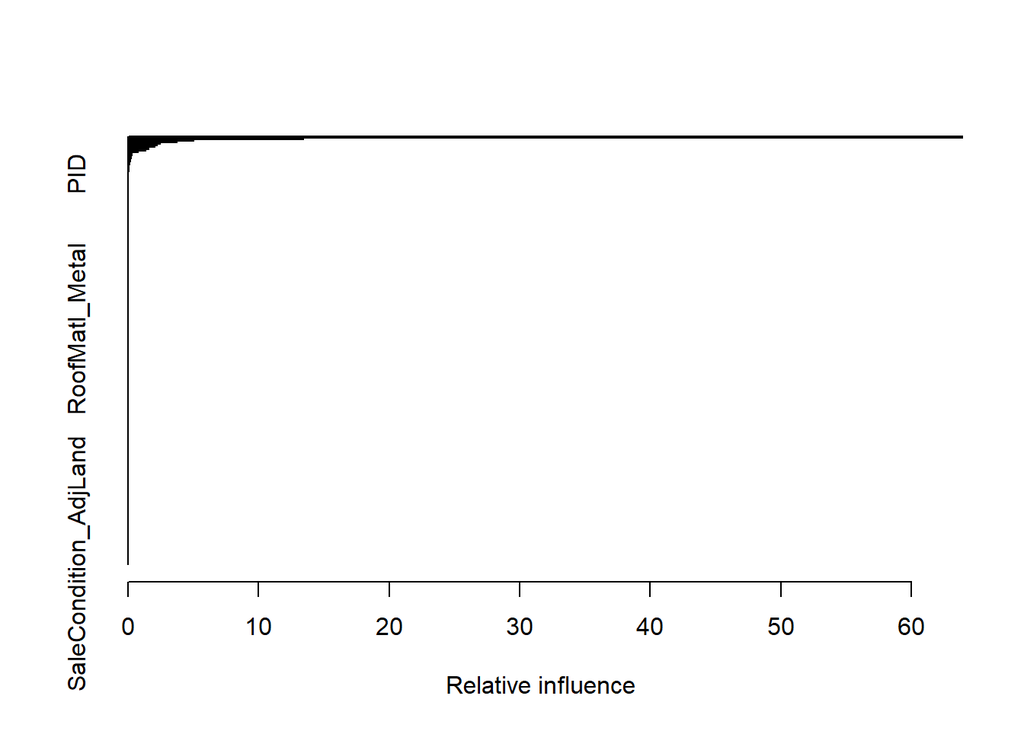

```
##                       var   rel.inf
## OverallQual   OverallQual 63.902825
## GrLivArea       GrLivArea 13.403990
## GarageCars_3 GarageCars_3  5.024785
## TotalBsmtSF   TotalBsmtSF  3.770163
## BsmtQual_Ex   BsmtQual_Ex  2.463716
## X1stFlrSF       X1stFlrSF  2.200320
## YearBuilt       YearBuilt  2.056381
## FullBath         FullBath  1.564799
## GarageArea     GarageArea  1.561966
## BsmtFinSF1     BsmtFinSF1  1.372851
```

```r
head(summary(AmesBoost), 10)
```

A table in the *README.md* file compares the results of the five feature selection tests.

The selection rule for features was this: if any of the top 10 features is selected by at least two of the five methods, it will be included in the Principal Components Analysis. As it happens, 11 features passed the test. So we create a new *tibble* with just these features. The PCA will determine which 10 combinations of these 11 features are most important to our analysis going forward.

### Principal Components Analysis

We want to identify the principal components (PCs) of these top 11 features because we need to how to build out the multilinear regression model we will eventually run to predict *SalePrice*. We are going to run a principal components regression, in other words, on the data. The PCs we identify will become the variables in the regression model.

A PC is defined by Chris Albon (@chrisalbon on Twitter) as “the linear combination of features that have the maximum variance out of all linear combinations.”

The first PC (PC1) is basically the line of best fit for the data we are dealing with. The direction of PC1 indicates the line along which the data vary the most. As will be seen, PC1 in this analysis consists of negative values for all features. This suggests that each of these features is below average in terms of PC1, when compared to corresponding values in subsequent PCs. These relationships will be depicted later graphically.

PC2 is the linear combination of the same 11 features that is uncorrelated to PC1. Because of this, the direction of PC2 is perpendicular to the direction of PC1. PC2 is said to be “orthogonal” to PC1. Because PC1 and PC2 are orthogonal, they contain more information combined than either one does individually. The way PCA works, PC1 contains the most information.

We continue to add PCs to the mix, building on orthogonal relationships between the 11 features, until we find the right number that contains the most information about the data set without overcomplicating the model. Each subsequent PC is uncorrelated (or orthogonal) to the preceding PC and it conveys less information than its immediate predecessor.

Of course, the effectiveness of this approach depends on two crucial assumptions. First, we assume the features we have chosen from the larger data set are in fact the most appropriate features to use. Second, we assume that a relatively small set of PCs can explain most of the data. In other words, we assume the directions associated with our PCs are the same directions associated with our target, which is *SalePrice* in the *Ames* case.

To begin, we create a data frame consisting of the 11 features chosen earlier.

```r
AmesPCAMeths <- as.tibble(AmesDumScaleDF[, c(15, 12, 17, 16, 33, 9, 19, 7, 250, 172, 27)])
str(AmesPCAMeths)
```

```
## Classes 'tbl_df', 'tbl' and 'data.frame':    2925 obs. of  11 variables:
##  $ TotalBsmtSF : atomic  0.0788 -0.3915 0.6702 2.5251 -0.2822 ...
##   ..- attr(*, "scaled:center")= Named num  1.46e+03 7.14e+08 5.74e+01 6.89e+01 1.01e+04 ...
##   .. ..- attr(*, "names")= chr  "Order" "PID" "MSSubClass" "LotFrontage" ...
##   ..- attr(*, "scaled:scale")= Named num  8.46e+02 1.89e+08 4.27e+01 2.07e+01 7.78e+03 ...
##   .. ..- attr(*, "names")= chr  "Order" "PID" "MSSubClass" "LotFrontage" ...
##  $ BsmtFinSF1  : atomic  0.4588 0.0683 1.1072 1.4315 0.8058 ...
##   ..- attr(*, "scaled:center")= Named num  1.46e+03 7.14e+08 5.74e+01 6.89e+01 1.01e+04 ...
##   .. ..- attr(*, "names")= chr  "Order" "PID" "MSSubClass" "LotFrontage" ...
##   ..- attr(*, "scaled:scale")= Named num  8.46e+02 1.89e+08 4.27e+01 2.07e+01 7.78e+03 ...
##   .. ..- attr(*, "names")= chr  "Order" "PID" "MSSubClass" "LotFrontage" ...
##  $ X2ndFlrSF   : atomic  -0.784 -0.784 -0.784 -0.784 0.862 ...
##   ..- attr(*, "scaled:center")= Named num  1.46e+03 7.14e+08 5.74e+01 6.89e+01 1.01e+04 ...
##   .. ..- attr(*, "names")= chr  "Order" "PID" "MSSubClass" "LotFrontage" ...
##   ..- attr(*, "scaled:scale")= Named num  8.46e+02 1.89e+08 4.27e+01 2.07e+01 7.78e+03 ...
##   .. ..- attr(*, "names")= chr  "Order" "PID" "MSSubClass" "LotFrontage" ...
##  $ X1stFlrSF   : atomic  1.329 -0.689 0.461 2.535 -0.604 ...
##   ..- attr(*, "scaled:center")= Named num  1.46e+03 7.14e+08 5.74e+01 6.89e+01 1.01e+04 ...
##   .. ..- attr(*, "names")= chr  "Order" "PID" "MSSubClass" "LotFrontage" ...
##   ..- attr(*, "scaled:scale")= Named num  8.46e+02 1.89e+08 4.27e+01 2.07e+01 7.78e+03 ...
##   .. ..- attr(*, "names")= chr  "Order" "PID" "MSSubClass" "LotFrontage" ...
##  $ PoolArea    : atomic  -0.0574 -0.0574 -0.0574 -0.0574 -0.0574 ...
##   ..- attr(*, "scaled:center")= Named num  1.46e+03 7.14e+08 5.74e+01 6.89e+01 1.01e+04 ...
##   .. ..- attr(*, "names")= chr  "Order" "PID" "MSSubClass" "LotFrontage" ...
##   ..- attr(*, "scaled:scale")= Named num  8.46e+02 1.89e+08 4.27e+01 2.07e+01 7.78e+03 ...
##   .. ..- attr(*, "names")= chr  "Order" "PID" "MSSubClass" "LotFrontage" ...
##  $ YearBuilt   : atomic  -0.374 -0.341 -0.44 -0.109 0.85 ...
##   ..- attr(*, "scaled:center")= Named num  1.46e+03 7.14e+08 5.74e+01 6.89e+01 1.01e+04 ...
##   .. ..- attr(*, "names")= chr  "Order" "PID" "MSSubClass" "LotFrontage" ...
##   ..- attr(*, "scaled:scale")= Named num  8.46e+02 1.89e+08 4.27e+01 2.07e+01 7.78e+03 ...
##   .. ..- attr(*, "names")= chr  "Order" "PID" "MSSubClass" "LotFrontage" ...
##  $ GrLivArea   : atomic  0.333 -1.23 -0.339 1.267 0.278 ...
##   ..- attr(*, "scaled:center")= Named num  1.46e+03 7.14e+08 5.74e+01 6.89e+01 1.01e+04 ...
##   .. ..- attr(*, "names")= chr  "Order" "PID" "MSSubClass" "LotFrontage" ...
##   ..- attr(*, "scaled:scale")= Named num  8.46e+02 1.89e+08 4.27e+01 2.07e+01 7.78e+03 ...
##   .. ..- attr(*, "names")= chr  "Order" "PID" "MSSubClass" "LotFrontage" ...
##  $ OverallQual : atomic  -0.0629 -0.7757 -0.0629 0.6499 -0.7757 ...
##   ..- attr(*, "scaled:center")= Named num  1.46e+03 7.14e+08 5.74e+01 6.89e+01 1.01e+04 ...
##   .. ..- attr(*, "names")= chr  "Order" "PID" "MSSubClass" "LotFrontage" ...
##   ..- attr(*, "scaled:scale")= Named num  8.46e+02 1.89e+08 4.27e+01 2.07e+01 7.78e+03 ...
##   .. ..- attr(*, "names")= chr  "Order" "PID" "MSSubClass" "LotFrontage" ...
##  $ GarageCars_3: atomic  -0.38 -0.38 -0.38 -0.38 -0.38 ...
##   ..- attr(*, "scaled:center")= Named num  1.46e+03 7.14e+08 5.74e+01 6.89e+01 1.01e+04 ...
##   .. ..- attr(*, "names")= chr  "Order" "PID" "MSSubClass" "LotFrontage" ...
##   ..- attr(*, "scaled:scale")= Named num  8.46e+02 1.89e+08 4.27e+01 2.07e+01 7.78e+03 ...
##   .. ..- attr(*, "names")= chr  "Order" "PID" "MSSubClass" "LotFrontage" ...
##  $ BsmtQual_Ex : atomic  -0.308 -0.308 -0.308 -0.308 -0.308 ...
##   ..- attr(*, "scaled:center")= Named num  1.46e+03 7.14e+08 5.74e+01 6.89e+01 1.01e+04 ...
##   .. ..- attr(*, "names")= chr  "Order" "PID" "MSSubClass" "LotFrontage" ...
##   ..- attr(*, "scaled:scale")= Named num  8.46e+02 1.89e+08 4.27e+01 2.07e+01 7.78e+03 ...
##   .. ..- attr(*, "names")= chr  "Order" "PID" "MSSubClass" "LotFrontage" ...
##  $ GarageArea  : atomic  0.2625 1.2074 -0.7479 0.2344 0.0473 ...
##   ..- attr(*, "scaled:center")= Named num  1.46e+03 7.14e+08 5.74e+01 6.89e+01 1.01e+04 ...
##   .. ..- attr(*, "names")= chr  "Order" "PID" "MSSubClass" "LotFrontage" ...
##   ..- attr(*, "scaled:scale")= Named num  8.46e+02 1.89e+08 4.27e+01 2.07e+01 7.78e+03 ...
##   .. ..- attr(*, "names")= chr  "Order" "PID" "MSSubClass" "LotFrontage" ...
```

We can subject the data to a PCA and collect the results in summarized form.

```r
AmesPCA <- pca(AmesPCAMeths, method = 'svd', center = FALSE, nPcs = 10)
AmesPCA
```

```
## svd calculated PCA
## Importance of component(s):
##                  PC1    PC2    PC3     PC4     PC5     PC6     PC7     PC8
## R2            0.4051 0.1599 0.0948 0.07762 0.06793 0.06312 0.05357 0.03212
## Cumulative R2 0.4051 0.5650 0.6598 0.73743 0.80536 0.86848 0.92205 0.95417
##                   PC9    PC10
## R2            0.02657 0.01892
## Cumulative R2 0.98074 0.99966
## 11   Variables
## 2925     Samples
## 0    NAs ( 0 %)
## 10   Calculated component(s)
## Data was NOT mean centered before running PCA
## Data was NOT scaled before running PCA
## Scores structure:
## [1] 2925   10
## Loadings structure:
## [1] 11 10
```

```r
summary(AmesPCA)
```

```
## svd calculated PCA
## Importance of component(s):
##                  PC1    PC2    PC3     PC4     PC5     PC6     PC7     PC8
## R2            0.4051 0.1599 0.0948 0.07762 0.06793 0.06312 0.05357 0.03212
## Cumulative R2 0.4051 0.5650 0.6598 0.73743 0.80536 0.86848 0.92205 0.95417
##                   PC9    PC10
## R2            0.02657 0.01892
## Cumulative R2 0.98074 0.99966
```

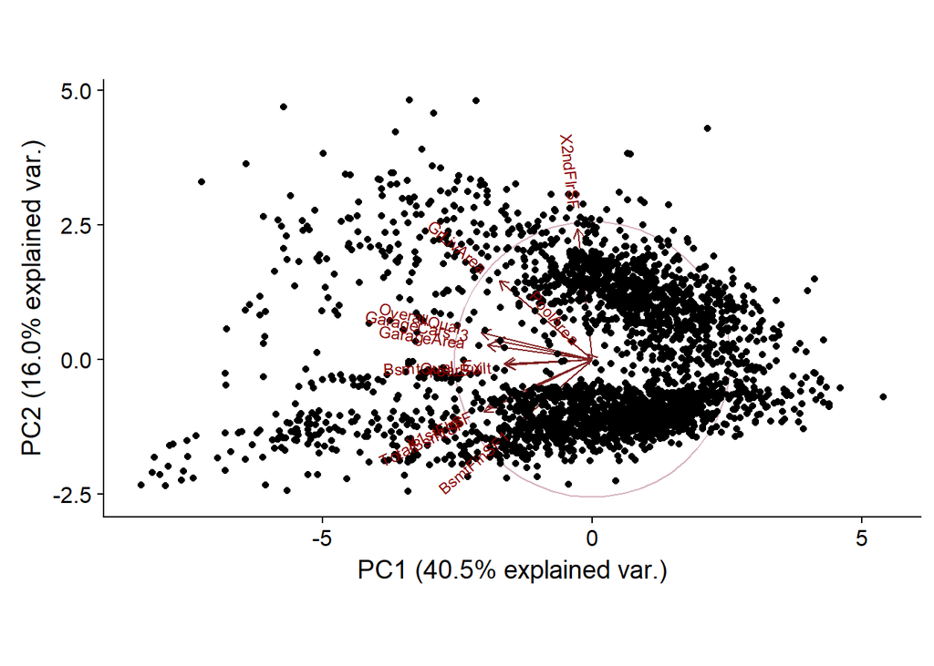

```r
AmesPCA2 <- prcomp(AmesPCAMeths)
ggbiplot::ggbiplot(AmesPCA2, obs.scale = 1, var.scale = 1, ellipse = TRUE, circle = TRUE) +
        scale_color_discrete(name = '') +
        theme(legend.direction = 'horizontal', legend.position = 'top')
```

We are looking for orthogonality between features, and the chart above displays some orthogonal relationships. It appears the nearly vertical red line, *X2ndFlrSF* is orthogonal to *BsmtQual_Ex* and *YearBuilt*, so there are three features we can consider. It also appears the two red lines between 10 o’clock and 11 o’clock, *GrLivArea* and *PoolArea*, are orthogonal to *BsmtFinSF1*. We have another three features to consider. In these two PCs there are for total of six features of interest.

We can also compare the loadings of all 10 PCs to get a sense of their structure and direction. First, we arrange the data set

```r
AmesLoad <- loadings(AmesPCA)
AmesLoad
```

```
##                      PC1         PC2         PC3         PC4         PC5
## TotalBsmtSF  -0.37325603 -0.28684388 -0.08907971 -0.23298131  0.12065399
## BsmtFinSF1   -0.23962063 -0.32796687 -0.05961810 -0.10987786  0.25460739
## X2ndFlrSF    -0.04969298  0.71736020 -0.01860356 -0.09896304  0.14318081
## X1stFlrSF    -0.36061095 -0.25941545 -0.23249910 -0.37142447  0.03150384
## PoolArea     -0.01591112  0.02943620 -0.88873267  0.43123913 -0.12590853
## YearBuilt    -0.29634226 -0.03178862  0.22109094  0.60823453  0.44433778
## GrLivArea    -0.32085398  0.43172401 -0.20485842 -0.38736125  0.14306654
## OverallQual  -0.38225826  0.14832171  0.09614477  0.18885229  0.19689054
## GarageCars_3 -0.33434865  0.10624966  0.13757020  0.07275359 -0.54387139
## BsmtQual_Ex  -0.30228738 -0.02218145  0.15048432  0.11740167 -0.57234865
## GarageArea   -0.36117171  0.07882471  0.05098734  0.15871407 -0.05676664
##                       PC6          PC7         PC8         PC9        PC10
## TotalBsmtSF  -0.132950791  0.139141470 -0.21480213 -0.05679882  0.78436251
## BsmtFinSF1    0.734691859 -0.434577399 -0.07911976 -0.03701913 -0.13526131
## X2ndFlrSF     0.249117506 -0.057188776 -0.04011998  0.07732950  0.23150227
## X1stFlrSF    -0.272545590  0.168659245  0.12576243  0.21091715 -0.43502232
## PoolArea      0.046999164  0.003965257 -0.05251243 -0.02359741  0.04089156
## YearBuilt    -0.063383381  0.125706481 -0.03911778  0.52251356 -0.02112934
## GrLivArea     0.004748772  0.085152128  0.06309297  0.22801840 -0.13491878
## OverallQual  -0.030143513  0.288562205 -0.22856330 -0.73656636 -0.26316532
## GarageCars_3 -0.154117849 -0.385718250 -0.58883806  0.16213706 -0.10657062
## BsmtQual_Ex   0.450513720  0.467834658  0.33048142  0.08359789  0.07797027
## GarageArea   -0.268958827 -0.534865337  0.64320791 -0.20871247  0.12894888
```

It doesn’t look as though there are many strong correlations between our 10 PCs and the 11 features composing them. PC2 appears correlated to *X2ndFlrSF* and PC6 seems to be correlated to *BsmtFinSF1*. PC3 appears corrlated to *PoolArea*. PC9 seems correlated to *OverallQual* and PC10 to *TotalBsmtSF*, but that’s it.

Then we structure it for plotting.

```r
AmesMelt <- melt(AmesLoad)
colnames(AmesMelt)[1] <- 'names'
AmesMelt <- arrange(AmesMelt, names)
AmesMelt$X2 <- gsub('PC1', 'PC01', AmesMelt$X2)
AmesMelt$X2 <- gsub('PC2', 'PC02', AmesMelt$X2)
AmesMelt$X2 <- gsub('PC3', 'PC03', AmesMelt$X2)
AmesMelt$X2 <- gsub('PC4', 'PC04', AmesMelt$X2)
AmesMelt$X2 <- gsub('PC5', 'PC05', AmesMelt$X2)
AmesMelt$X2 <- gsub('PC6', 'PC06', AmesMelt$X2)
AmesMelt$X2 <- gsub('PC7', 'PC07', AmesMelt$X2)
AmesMelt$X2 <- gsub('PC8', 'PC08', AmesMelt$X2)
AmesMelt$X2 <- gsub('PC9', 'PC09', AmesMelt$X2)
AmesMelt$X2 <- gsub('PC010', 'PC10', AmesMelt$X2)
```

Run a sanity check to make sure the data are in the proper structure.

```r
AmesMelt
```

```
##            names   X2        value
## 1     BsmtFinSF1 PC01 -0.239620634
## 2     BsmtFinSF1 PC02 -0.327966870
## 3     BsmtFinSF1 PC03 -0.059618101
## 4     BsmtFinSF1 PC04 -0.109877858
## 5     BsmtFinSF1 PC05  0.254607389
## 6     BsmtFinSF1 PC06  0.734691859
## 7     BsmtFinSF1 PC07 -0.434577399
## 8     BsmtFinSF1 PC08 -0.079119756
## 9     BsmtFinSF1 PC09 -0.037019132
## 10    BsmtFinSF1 PC10 -0.135261313
## 11   BsmtQual_Ex PC01 -0.302287381
## 12   BsmtQual_Ex PC02 -0.022181455
## 13   BsmtQual_Ex PC03  0.150484321
## 14   BsmtQual_Ex PC04  0.117401671
```

[output cut: 96 more lines]

We will come back to this in the next section on clustering.

A quick way to determine which features are most important is to plot the standard deviations from the PCA for each principal component and see “where the line breaks.” The following graph suggests two features definitely, though an argument can be made that three, possibly four, features contribute more to our understanding of the data. Even if we choose to use just two PCs, we know from the chart above there are six features arranged in an orthogonal manner.

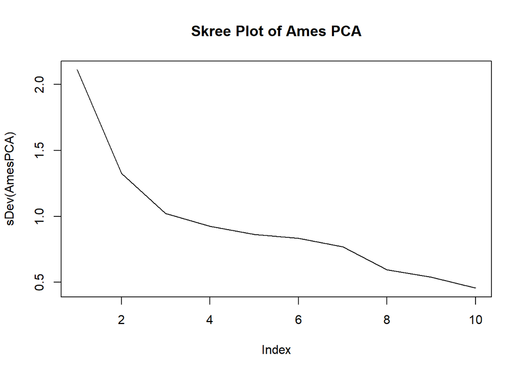

```r
plot(sDev(AmesPCA), type = "lines", main = 'Skree Plot of Ames PCA')
```

Another way to look at the PCA results is with a pair plot. But taking all 10 PCs into consideration might be a bit much.

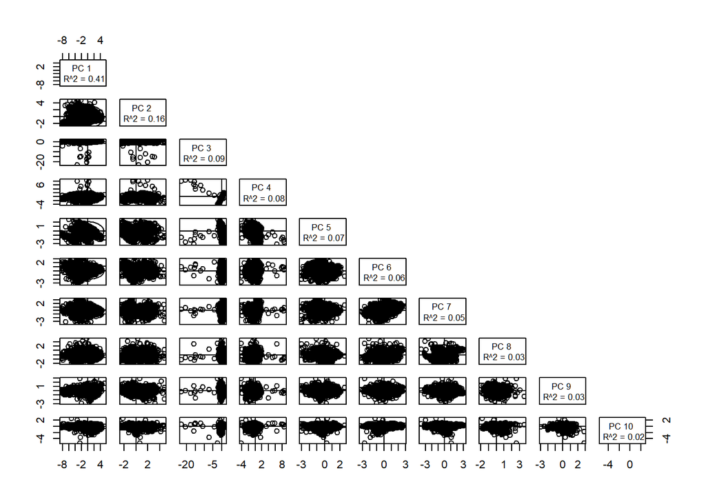

```r
plotPcs(AmesPCA)
```

Definitely. Since our skree plot suggests three or four PCs are sufficient, let’s pare down the pairs plots to two pair.

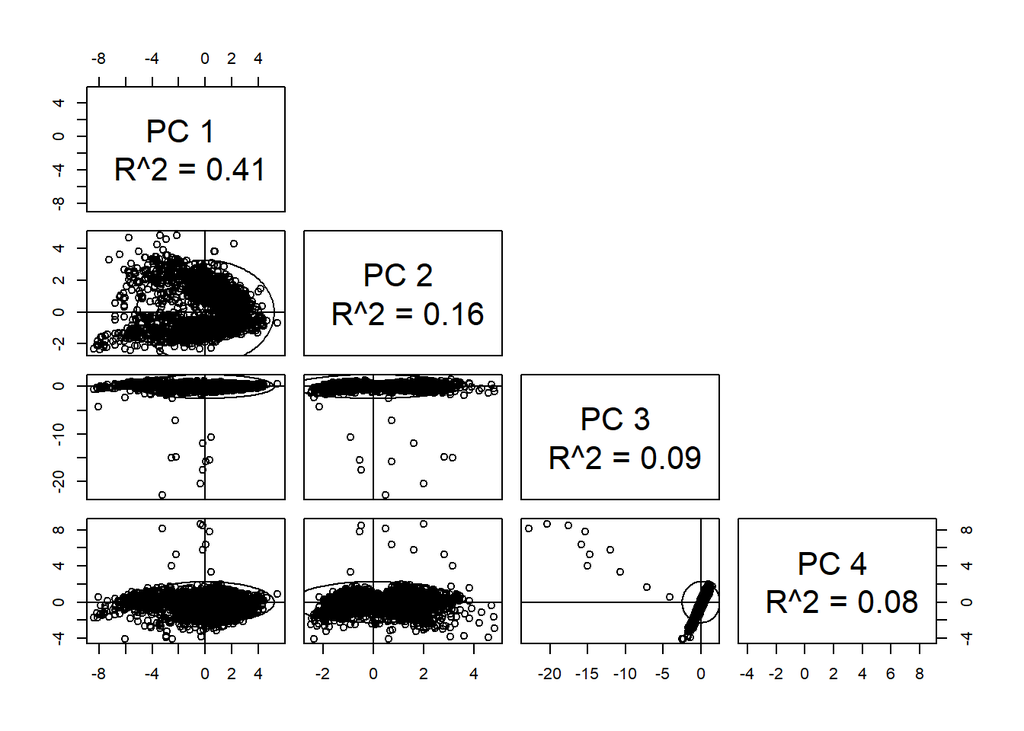

```r
plotPcs(AmesPCA, pcs = 1:4)
```

The following set of graphs compares PC1 to PC2, PC3, and PC4 in greater detail and includes analysis of the loadings.

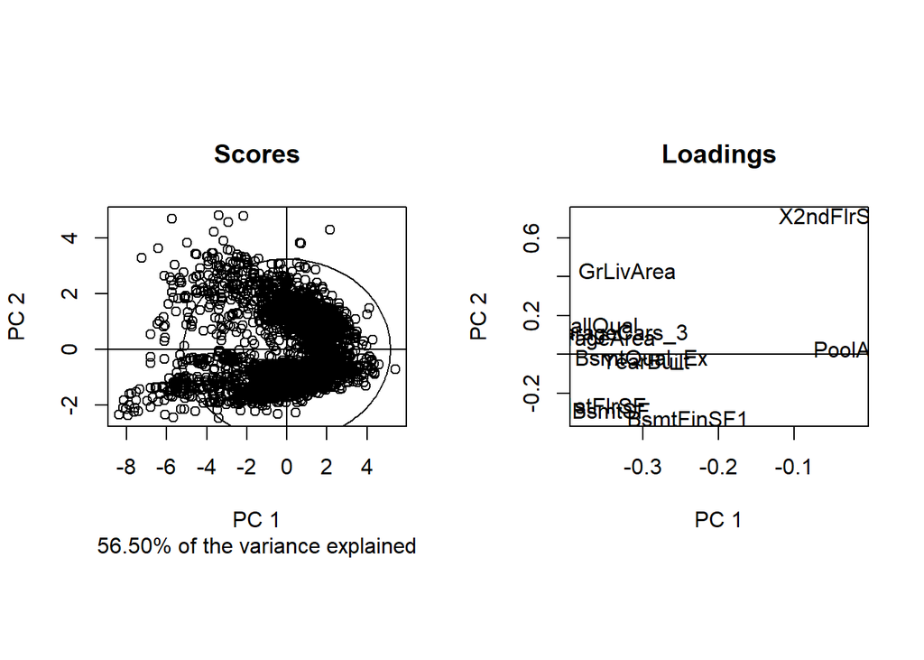

```r
slplot(AmesPCA, pcs = c(1, 2))
```

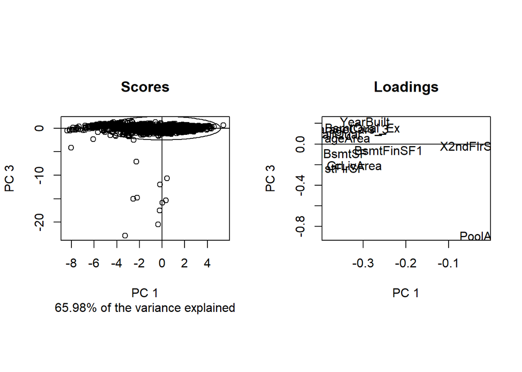

```r
slplot(AmesPCA, pcs = c(1, 3))
```

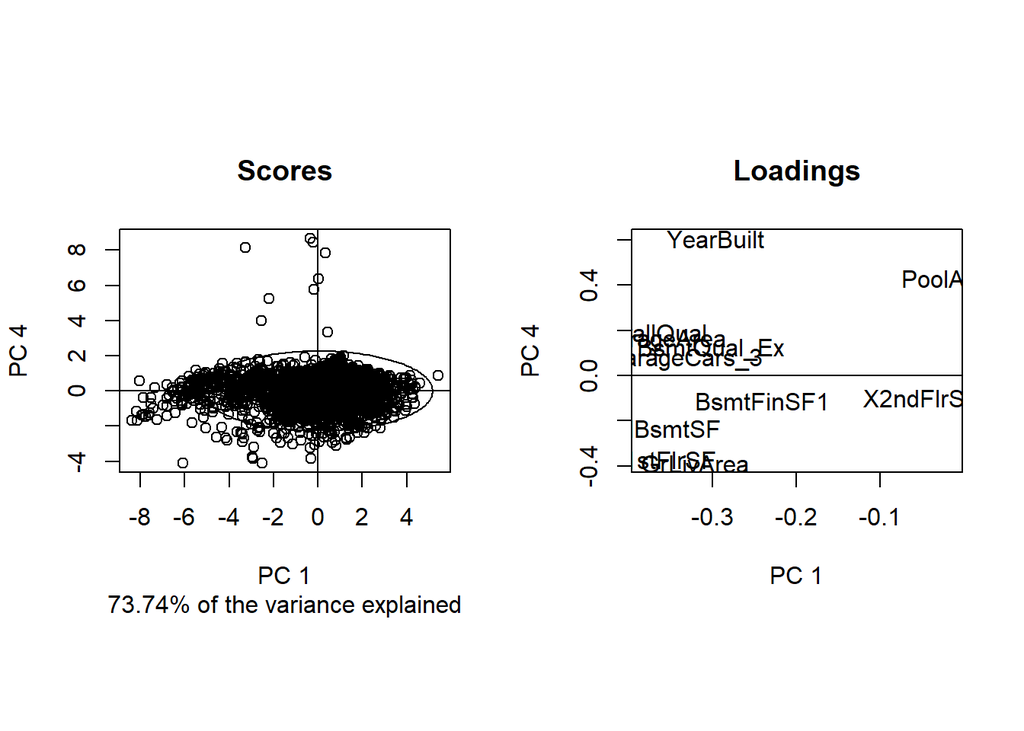

```r
slplot(AmesPCA, pcs = c(1, 4))
```

Here, we compare PC2 with PC3 and PC4.

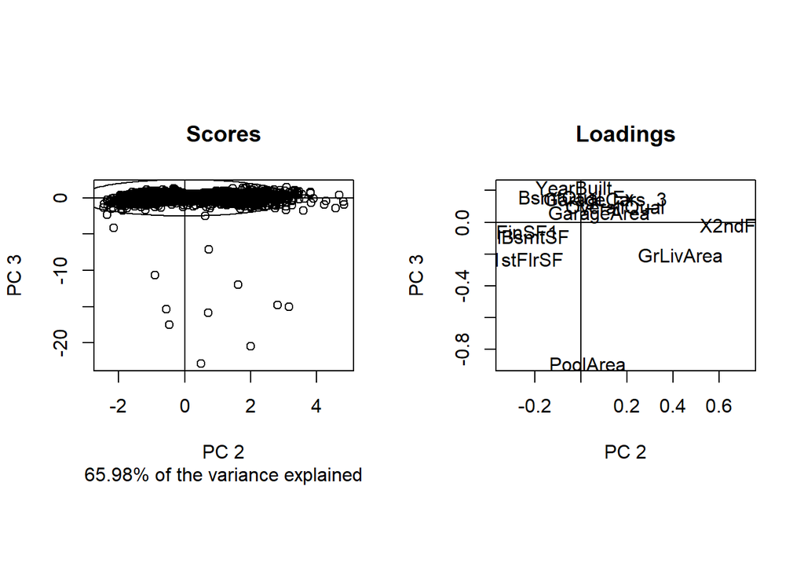

```r
slplot(AmesPCA, pcs = c(2, 3))
```

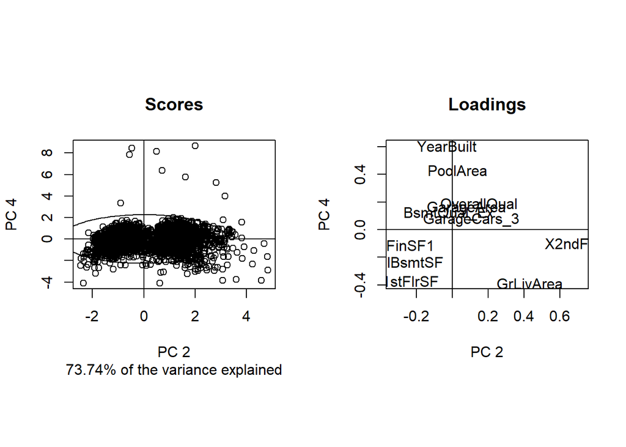

```r
slplot(AmesPCA, pcs = c(2, 4))
```

We complete the set with a graph of PC3 and PC4.

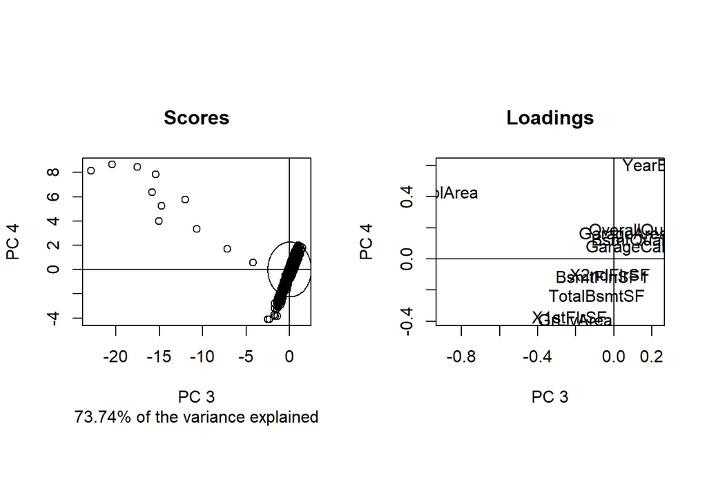

```r
slplot(AmesPCA, pcs = c(3, 4))
```

Then produce a visualization of the loadings.

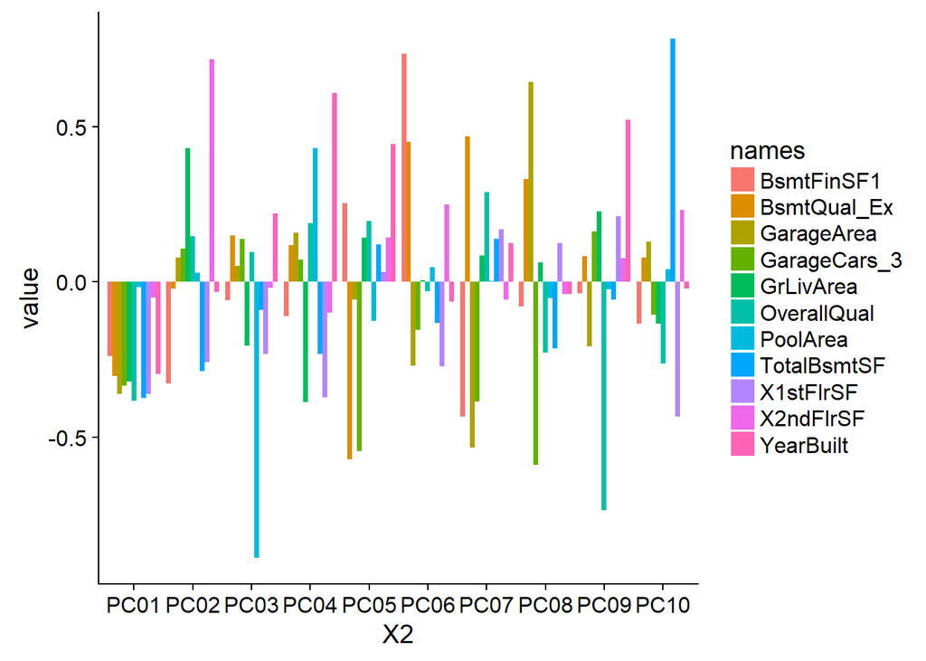

```r
ggplot(AmesMelt, aes(x = X2, y = value, fill = names)) + geom_bar(stat = 'identity',
        position = 'dodge') + guides(fill = guide_legend(reverse = FALSE))
```

As mentioned earlier, there are five features that dominate the PCs. It doesn’t look as though there are many strong correlations between our 10 PCs and the 11 features composing them. In PC2 there is *X2ndFlrSF*. PC6 is dominated by *BsmtFinSF1* while *PoolArea* dominates PC3. PC9’s dominant feature is *OverallQual* and PC10 is characterized by *TotalBsmtSF*. We can see these features in the loading graph above. This suggest we should include these five when building our multilinear regression model.

We also mentioned earlier that PC1 consists of negative values only, suggesting the most important PC, the one that accounts for most of the variation in the data, is related somehow to below average housing features.

It is possible to cross validate the PCA results by using the *Q<sup>2</sup>* measure, a cross-validation version of *R<sup>2</sup>*. It is the ratio of variance predicted independently by the PCA model.

```r
q2svd <- Q2(AmesPCA, AmesPCAMeths, fold = 15, nruncv = 1)
q2svd
```

```
##      PC 1      PC 2      PC 3      PC 4      PC 5      PC 6      PC 7
## 0.2942543 0.3397652 0.2808441 0.2545190 0.2069783 0.1856758 0.2139185
##      PC 8      PC 9     PC 10
## 0.1981492 0.1951924 0.2127118
```

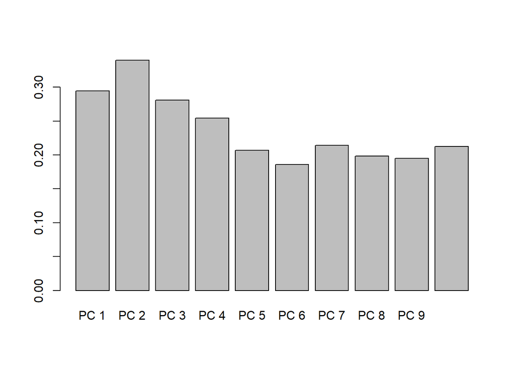

```r
barplot(q2svd)
```

### Clustering

We have an idea of how many PCs are important to our understanding of the *Ames* data structure, so we can use clustering to confirm our findings. We will use a k-means cluster method so it is important to measure clusters in terms appropriate for k-means analysis. In this case, we will work with squared distances. The resulting silhouette chart demonstrates the results.

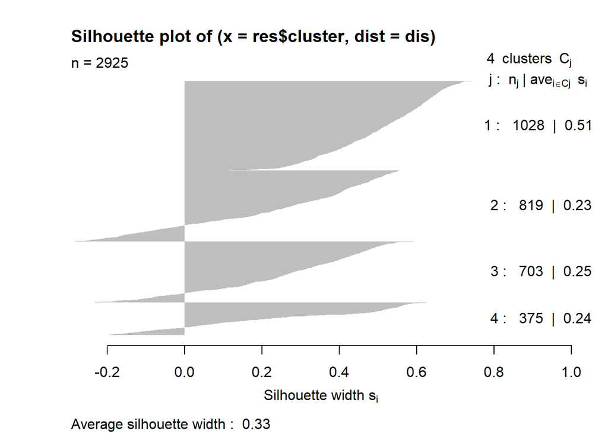

```r
dis <- dist(AmesPCAMeths)^2
res <- kmeans(AmesPCAMeths, 4)
sil <- silhouette(res$cluster, dis)
windows()
plot(sil)
```

We can consider the four clusters from a different perspective with scatterplots. First we calculate the data and determine which cluster each data point belongs to.

```r
AmesCl <- kmeans(AmesPCAMeths, 4, nstart = 10)
AmesCl
```

```
## K-means clustering with 4 clusters of sizes 1028, 375, 819, 703
##
## Cluster means:
##   TotalBsmtSF BsmtFinSF1  X2ndFlrSF  X1stFlrSF    PoolArea  YearBuilt
## 1  -0.6694657 -0.3847359 -0.2996653 -0.6469502 -0.05743592 -0.8109677
## 2   1.3842824  0.8425579  0.1513656  1.3188245 -0.04578695  1.0051568
## 3   0.5841330  0.3838242 -0.7693100  0.6130855  0.06038876  0.3227847
## 4  -0.4399717 -0.3340011  1.2537108 -0.4717090  0.03805951  0.2736562
##    GrLivArea OverallQual GarageCars_3 BsmtQual_Ex GarageArea
## 1 -0.7586944 -0.82488237   -0.3599980  -0.2972776 -0.7646579
## 2  1.1474140  1.50144830    2.1220468   1.7790641  1.4552508
## 3 -0.2055015  0.07028607   -0.3364084  -0.2251408  0.1857148
## 4  0.7367899  0.32343055   -0.2136147  -0.2520019  0.1255318
##
## Clustering vector:
```

[output cut: 97 more lines]

We group the data into four clusters, each designated by a circle. The clusters are distinct but they tend to intermingle with the other clusters, resembling a Venn diagram with overlapping areas. The leftmost cluster seems particularly dispersed. Reducing the clusters to three did not improve things much so we will stick with four PCs, despite the fact that the clustering seems to be falling apart.

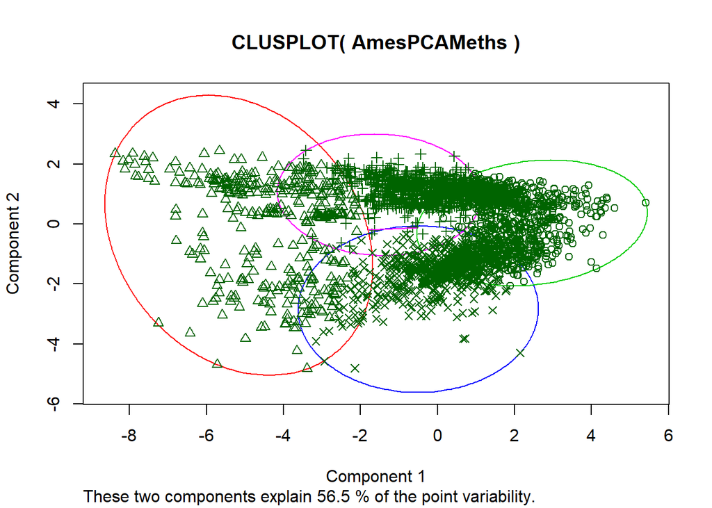

```r
clusplot(AmesPCAMeths, AmesCl$cluster, color = TRUE)
```

Finally, we group cluster members by color to get a better sense of how they disperse and how much they intermingle.

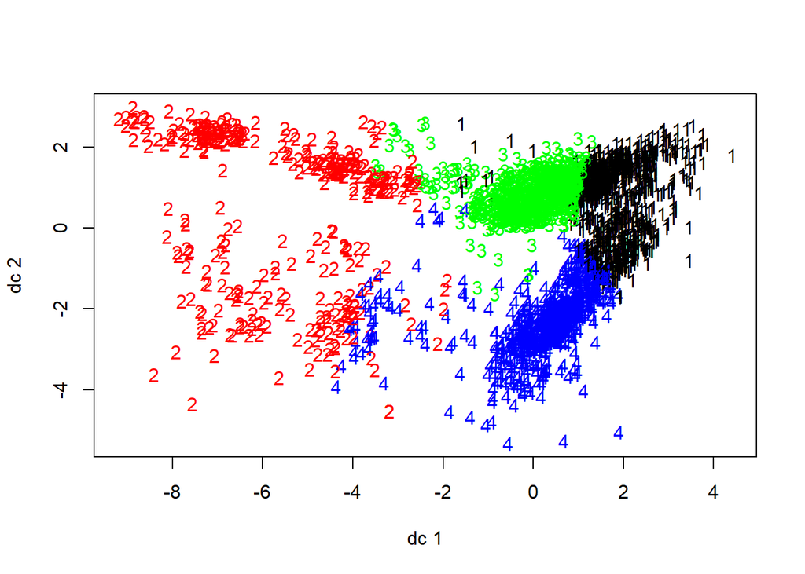

```r
plotcluster(AmesPCAMeths, AmesCl$cluster)
```

The patterns appear pretty tight, except for the left-most cluster. A lot of variability (and so uncertainty) in the model resides there.